# STA465 Final Exam

Tianyi Zhang

29/04/2022

# Fitting Models

```r
#### Fit models ####
# Using Default Priors
##### Complete pooling and altitude covariate (no random effect) #####
formula1 <- prev ~ 1 + alt
res1 <- inla(formula1, data = gambia.sf,
            control.predictor = list(compute = TRUE),
            control.compute = list(cpo=TRUE))

##### Hierarchical random effect (iid) - (intercept only) #####
# Include an unstructured component with index variable
gambia.sf$idu <- 1:nrow(gambia.sf)
gambia.sf$idv <- 1:nrow(gambia.sf)

formula2 <- prev ~ 1 + f(idv, model = "iid")
res2 <- inla(formula2, data = gambia.sf,
            control.predictor = list(compute = TRUE),
            control.compute = list(cpo=TRUE))

##### Hierarchical random effect (iid) + altitude covariate #####
formula3 <- prev ~ 1 + alt + f(idu, model = "iid") +
  f(idv, alt, model = "iid")
res3 <- inla(formula3, data = gambia.sf,
            control.predictor = list(compute = TRUE),
            control.compute = list(cpo=TRUE))

##### Spatial + iid random effect ; Default Priors #####
## Mesh Construction
# Code modified from MalariaPrevalence.Rmd in Lab 7
coo <- cbind(d$long, d$lat)
mesh <- inla.mesh.2d(
  loc = coo, max.edge = c(0.1, 5),
  cutoff = 0.01
)

## Construct "A" projection matrices
# SPDE with default priors
spde <- inla.spde2.matern(mesh = mesh, alpha = 2, constr = TRUE)

indexs <- inla.spde.make.index("s", spde$n.spde)
A <- inla.spde.make.A(mesh = mesh, loc = coo)

## Prediction data
dp <- rasterToPoints(r)
ra <- aggregate(r, fact = 5, fun = mean)
dp <- rasterToPoints(ra)
coop <- dp[, c("x", "y")]
Ap <- inla.spde.make.A(mesh = mesh, loc = coop)

## stack for estimation stk.e
stk.e <- inla.stack(
  tag = "est",
  data = list(y = d$positive, numtrials = d$total),
  A = list(1, A),
  effects = list(data.frame(b0 = 1, altitude = d$alt), s = indexs)
)

# stack for prediction stk.p
stk.p <- inla.stack(
  tag = "pred",
  data = list(y = NA, numtrials = NA),
  A = list(1, Ap),
  effects = list(data.frame(b0 = 1, altitude = dp[, 3]),
    s = indexs
  )
)

# stk.full has stk.e and stk.p
stk.full <- inla.stack(stk.e, stk.p)

###### Model formula and inla call ######
formula4.1 <- y ~ 0 + b0 + f(s, model = spde)

res4.1 <- inla(formula4.1,
  data = inla.stack.data(stk.full),
  control.predictor = list(
    compute = TRUE,
    A = inla.stack.A(stk.full)
  ),
  control.compute = list(cpo=TRUE)
)

##### Spatial + iid random effect ; PC Priors #####
## Mesh Construction
# Code modified from MalariaPrevalence.Rmd in Lab 7
coo <- cbind(d$long, d$lat)
mesh <- inla.mesh.2d(
  loc = coo, max.edge = c(0.1, 5),
  cutoff = 0.01
)

## Construct "A" projection matrices
# SPDE2 Matérn with penalized complexity priors
spde.pc <- inla.spde2.pcmatern(mesh = mesh, alpha = 2, constr = TRUE,
                            prior.range = c(10, 0.9), prior.sigma = c(1, 0.01))

indexs <- inla.spde.make.index("s", spde.pc$n.spde)
A <- inla.spde.make.A(mesh = mesh, loc = coo)

## Prediction data
dp <- rasterToPoints(r)
ra <- aggregate(r, fact = 5, fun = mean)
dp <- rasterToPoints(ra)
coop <- dp[, c("x", "y")]
Ap <- inla.spde.make.A(mesh = mesh, loc = coop)

## stack for estimation stk.e
stk.e <- inla.stack(
  tag = "est",
  data = list(y = d$positive, numtrials = d$total),
  A = list(1, A),
  effects = list(data.frame(b0 = 1, altitude = d$alt), s = indexs)
)

# stack for prediction stk.p
stk.p <- inla.stack(
  tag = "pred",
  data = list(y = NA, numtrials = NA),
  A = list(1, Ap),
  effects = list(data.frame(b0 = 1, altitude = dp[, 3]),
    s = indexs
  )
)

# stk.full has stk.e and stk.p
stk.full <- inla.stack(stk.e, stk.p)

###### Model formula and inla call ######
formula4.2 <- y ~ 0 + b0 + f(s, model = spde.pc)

res4.2 <- inla(formula4.2,
  data = inla.stack.data(stk.full),
  control.predictor = list(
    compute = TRUE,
    A = inla.stack.A(stk.full)
  ),
  control.compute = list(cpo=TRUE)
)


##### Spatial + iid random effect + altitude covariate ; Default Priors #####
## Mesh Construction
coo <- cbind(d$long, d$lat)
mesh <- inla.mesh.2d(
  loc = coo, max.edge = c(0.1, 5),
  cutoff = 0.01
)

## Construct "A" projection matrices
# SPDE with default priors
spde <- inla.spde2.matern(mesh = mesh, alpha = 2, constr = TRUE)

indexs <- inla.spde.make.index("s", spde.pc$n.spde)
A <- inla.spde.make.A(mesh = mesh, loc = coo)

## Prediction data
dp <- rasterToPoints(r)
ra <- aggregate(r, fact = 5, fun = mean)
dp <- rasterToPoints(ra)
coop <- dp[, c("x", "y")]
Ap <- inla.spde.make.A(mesh = mesh, loc = coop)

## stack for estimation stk.e
stk.e <- inla.stack(
  tag = "est",
  data = list(y = d$positive, numtrials = d$total),
  A = list(1, A),
  effects = list(data.frame(b0 = 1, altitude = d$alt), s = indexs)
)

# stack for prediction stk.p
stk.p <- inla.stack(
  tag = "pred",
  data = list(y = NA, numtrials = NA),
  A = list(1, Ap),
  effects = list(data.frame(b0 = 1, altitude = dp[, 3]),
    s = indexs
  )
)

# stk.full has stk.e and stk.p
stk.full <- inla.stack(stk.e, stk.p)

###### Model formula and inla call ######
formula5.1 <- y ~ 0 + b0 + altitude + f(s, model = spde)

res5.1 <- inla(formula5.1,
  family = "binomial", Ntrials = numtrials,
  control.family = list(link = "logit"),
  data = inla.stack.data(stk.full),
  control.predictor = list(
    compute = TRUE, link = 1,
    A = inla.stack.A(stk.full)
  ),
  control.compute = list(cpo=TRUE)
)

##### Spatial + iid random effect + altitude covariate; PC Priors #####
## Mesh Construction
coo <- cbind(d$long, d$lat)
mesh <- inla.mesh.2d(
  loc = coo, max.edge = c(0.1, 5),
  cutoff = 0.01
)

## Construct "A" projection matrices
# SPDE2 Matérn with penalized complexity priors
spde.pc <- inla.spde2.pcmatern(mesh = mesh, alpha = 2, constr = TRUE,
                            prior.range = c(10, 0.9), prior.sigma = c(1, 0.01))


indexs <- inla.spde.make.index("s", spde.pc$n.spde)
A <- inla.spde.make.A(mesh = mesh, loc = coo)

## Prediction data
dp <- rasterToPoints(r)
ra <- aggregate(r, fact = 5, fun = mean)
dp <- rasterToPoints(ra)
coop <- dp[, c("x", "y")]
Ap <- inla.spde.make.A(mesh = mesh, loc = coop)

## stack for estimation stk.e
stk.e <- inla.stack(
  tag = "est",
  data = list(y = d$positive, numtrials = d$total),
  A = list(1, A),
  effects = list(data.frame(b0 = 1, altitude = d$alt), s = indexs)
)

# stack for prediction stk.p
stk.p <- inla.stack(
  tag = "pred",
  data = list(y = NA, numtrials = NA),
  A = list(1, Ap),
  effects = list(data.frame(b0 = 1, altitude = dp[, 3]),
    s = indexs
  )
)

# stk.full has stk.e and stk.p
stk.full <- inla.stack(stk.e, stk.p)

###### Model formula and inla call ######
formula5.2 <- y ~ 0 + b0 + altitude + f(s, model = spde.pc)

res5.2 <- inla(formula5.2,
  family = "binomial", Ntrials = numtrials,
  control.family = list(link = "logit"),
  data = inla.stack.data(stk.full),
  control.predictor = list(
    compute = TRUE, link = 1,
    A = inla.stack.A(stk.full)
  ),
  control.compute = list(cpo=TRUE)
)
```

## CPO + PIT Values

```r
#### CPO + PIT values ####
cpo1 <- data.frame(CPO = res1$cpo$cpo,
                       PIT = res1$cpo$pit)
cpo2 <- data.frame(CPO = res2$cpo$cpo,
                       PIT = res2$cpo$pit)
cpo3 <- data.frame(CPO = res3$cpo$cpo,
                       PIT = res3$cpo$pit)
cpo4.1 <- data.frame(CPO = res4.1$cpo$cpo,
                       PIT = res4.1$cpo$pit)
cpo4.2 <- data.frame(CPO = res4.2$cpo$cpo,
                       PIT = res4.2$cpo$pit)
cpo5.1 <- data.frame(CPO = res5.1$cpo$cpo,
                       PIT = res5.1$cpo$pit)
cpo5.2 <- data.frame(CPO = res5.2$cpo$cpo,
                       PIT = res5.2$cpo$pit)
cpo.total <- data.frame(cpo1,cpo2,cpo3,
                        cpo4.1[1:65,],cpo4.2[1:65,],cpo5.1[1:65,],cpo5.2[1:65,])

cpo.total |>
  kable(
    caption = "CPO and PIT values for each Model",
    row.names = FALSE,
    col.names = c("CPO","PIT","CPO","PIT","CPO",
                  "PIT","CPO","PIT",
                  "CPO","PIT","CPO",
                  "PIT","CPO",
                  "PIT"),
    digits = 4,
    booktabs = TRUE,
    align = 'l'
  ) |>
  add_header_above(c("Complete Pool" = 2, "Hierarchical" = 2,
                     "Hierchical+Alt" = 2, "Spatial+Default Priors" = 2,
                     "Spatial+PC Priors" = 2, "Spatial+Alt+Default Priors" = 2,
                     "Spatial+Alt+PC Priors" = 2))
```

CPO and PIT values for each Model

| Complete Pool CPO | Complete Pool PIT | Hierarchical CPO | Hierarchical PIT | Hierchical+Alt CPO | Hierchical+Alt PIT | Spatial+Default Priors CPO | Spatial+Default Priors PIT | Spatial+PC Priors CPO | Spatial+PC Priors PIT | Spatial+Alt+Default Priors CPO | Spatial+Alt+Default Priors PIT | Spatial+Alt+PC Priors CPO | Spatial+Alt+PC Priors PIT |
| --- | --- | --- | --- | --- | --- | --- | --- | --- | --- | --- | --- | --- | --- |
| 1.2933 | 0.7886 | 5.5025 | 0.6063 | 1.3008 | 0.8228 | 0.0429 | 0.8417 | 0.0354 | 0.8840 | 0.0482 | 0.7057 | 0.0492 | 0.7204 |
| 1.5363 | 0.2908 | 5.5611 | 0.4261 | 1.3458 | 0.3081 | 0.0224 | 0.9402 | 0.0193 | 0.9484 | 0.0357 | 0.2379 | 0.0342 | 0.1962 |
| 1.7790 | 0.4639 | 5.4728 | 0.5240 | 1.4629 | 0.4567 | 0.0429 | 0.1459 | 0.0547 | 0.2243 | 0.1209 | 0.7572 | 0.1282 | 0.7763 |
| 1.7689 | 0.4309 | 5.5152 | 0.4516 | 1.8022 | 0.4293 | 0.0697 | 0.3652 | 0.0684 | 0.3534 | 0.0697 | 0.7081 | 0.0686 | 0.7525 |
| 1.7799 | 0.4511 | 5.4901 | 0.4985 | 1.5712 | 0.4470 | 0.0745 | 0.3976 | 0.0733 | 0.4518 | 0.0842 | 0.3104 | 0.0992 | 0.3638 |
| 1.7730 | 0.5594 | 5.4897 | 0.5026 | 1.8951 | 0.5675 | 0.0529 | 0.1937 | 0.0576 | 0.2418 | 0.1154 | 0.4455 | 0.1261 | 0.4593 |
| 0.6681 | 0.9186 | 4.7800 | 0.7010 | 0.5000 | 0.9525 | 0.0013 | 0.9978 | 0.0017 | 0.9969 | 0.0003 | 0.9997 | 0.0002 | 0.9998 |
| 0.7181 | 0.0890 | 4.6465 | 0.2847 | 0.7519 | 0.1150 | 0.0551 | 0.2059 | 0.0583 | 0.2465 | 0.0000 | 0.0000 | 0.0000 | 0.0000 |
| 0.4296 | 0.0469 | 4.4551 | 0.2675 | 0.5641 | 0.0978 | 0.0592 | 0.2417 | 0.0560 | 0.2304 | 0.0000 | 0.0000 | 0.0000 | 0.0000 |
| 1.3921 | 0.2445 | 5.5823 | 0.4315 | 1.1409 | 0.2850 | 0.0741 | 0.3995 | 0.0698 | 0.3692 | 0.0804 | 0.7669 | 0.0819 | 0.8109 |
| 1.5230 | 0.2922 | 5.2457 | 0.3453 | 1.7539 | 0.2669 | 0.0622 | 0.2555 | 0.0571 | 0.2359 | 0.0869 | 0.3627 | 0.0949 | 0.3679 |
| 1.7876 | 0.4610 | 5.4879 | 0.4895 | 1.6658 | 0.4571 | 0.0711 | 0.6569 | 0.0695 | 0.6372 | 0.0396 | 0.9014 | 0.0354 | 0.9305 |
| 1.7149 | 0.6190 | 5.4245 | 0.5483 | 1.7458 | 0.6210 | 0.0448 | 0.8507 | 0.0508 | 0.8045 | 0.0377 | 0.9022 | 0.0348 | 0.9282 |
| 1.6490 | 0.3455 | 5.5631 | 0.3910 | 1.8547 | 0.3343 | 0.0433 | 0.1422 | 0.0438 | 0.1543 | 0.1323 | 0.4036 | 0.1393 | 0.4014 |
| 0.9715 | 0.1362 | 4.3300 | 0.2573 | 0.9382 | 0.1062 | 0.0543 | 0.2022 | 0.0490 | 0.1826 | 0.0000 | 0.0000 | 0.0000 | 0.0000 |
| 1.1008 | 0.1628 | 4.7767 | 0.2965 | 1.1103 | 0.1450 | 0.0367 | 0.1117 | 0.0362 | 0.1167 | 0.0540 | 0.1395 | 0.0725 | 0.1691 |
| 1.7138 | 0.3916 | 5.5600 | 0.4011 | 1.9949 | 0.3862 | 0.0748 | 0.4014 | 0.0701 | 0.3729 | 0.0134 | 0.0337 | 0.0109 | 0.0240 |
| 0.7100 | 0.9122 | 3.8479 | 0.7780 | 0.7970 | 0.8714 | 0.0345 | 0.8963 | 0.0414 | 0.8569 | 0.0102 | 0.9895 | 0.0070 | 0.9942 |
| 1.4048 | 0.2427 | 5.3839 | 0.3627 | 1.4335 | 0.2356 | 0.0574 | 0.2237 | 0.0543 | 0.2171 | 0.0764 | 0.2340 | 0.0750 | 0.2060 |
| 1.5618 | 0.6864 | 5.4846 | 0.5130 | 1.6820 | 0.7547 | 0.0644 | 0.7183 | 0.0675 | 0.6615 | 0.0722 | 0.5862 | 0.0781 | 0.6058 |
| 1.4630 | 0.7377 | 5.4239 | 0.5995 | 1.5019 | 0.7509 | 0.0356 | 0.8897 | 0.0440 | 0.8432 | 0.0394 | 0.8935 | 0.0348 | 0.9244 |
| 1.6347 | 0.3446 | 5.5710 | 0.4854 | 1.2638 | 0.3644 | 0.0750 | 0.5856 | 0.0735 | 0.5328 | 0.0791 | 0.3283 | 0.0856 | 0.3236 |
| 1.4777 | 0.2753 | 5.5152 | 0.4516 | 1.1683 | 0.3121 | 0.0745 | 0.5963 | 0.0734 | 0.5355 | 0.0819 | 0.6563 | 0.0892 | 0.6776 |
| 0.6228 | 0.0740 | 3.6987 | 0.2066 | 0.5416 | 0.0536 | 0.0193 | 0.0496 | 0.0176 | 0.0460 | 0.0000 | 0.0000 | 0.0000 | 0.0000 |
| 1.0457 | 0.8489 | 4.5921 | 0.7181 | 1.0491 | 0.7991 | 0.0501 | 0.8149 | 0.0578 | 0.7530 | 0.0539 | 0.8784 | 0.0500 | 0.9015 |
| 1.3481 | 0.2253 | 5.3352 | 0.3564 | 1.3586 | 0.2207 | 0.0745 | 0.5380 | 0.0672 | 0.3497 | 0.0860 | 0.4346 | 0.0924 | 0.4482 |
| 1.7692 | 0.5603 | 5.4894 | 0.4936 | 1.9465 | 0.5736 | 0.0354 | 0.8874 | 0.0582 | 0.7361 | 0.0259 | 0.9323 | 0.0198 | 0.9593 |
| 0.8143 | 0.1062 | 4.0035 | 0.2306 | 0.7403 | 0.0775 | 0.0557 | 0.2200 | 0.0364 | 0.1197 | 0.0000 | 0.0000 | 0.0000 | 0.0000 |
| 0.3414 | 0.0348 | 3.4806 | 0.1894 | 0.3723 | 0.0411 | 0.0385 | 0.1214 | 0.0217 | 0.0598 | 0.0000 | 0.0000 | 0.0000 | 0.0000 |
| 0.2552 | 0.0247 | 3.4806 | 0.1894 | 0.3475 | 0.0434 | 0.0385 | 0.1212 | 0.0217 | 0.0598 | 0.2412 | 0.2412 | 0.2625 | 0.2625 |
| 0.9909 | 0.1386 | 4.8913 | 0.3074 | 0.9842 | 0.1441 | 0.0754 | 0.5499 | 0.0677 | 0.3577 | 0.0251 | 0.5062 | 0.0452 | 0.9287 |
| 1.2638 | 0.2048 | 4.8742 | 0.3057 | 1.3343 | 0.1742 | 0.0709 | 0.3465 | 0.0529 | 0.2117 | 0.1016 | 0.4150 | 0.1317 | 0.5393 |
| 1.3126 | 0.2168 | 5.0737 | 0.3261 | 1.3832 | 0.1950 | 0.0769 | 0.4880 | 0.0664 | 0.3327 | 0.1080 | 0.7363 | 0.1130 | 0.7536 |
| 0.8938 | 0.1201 | 4.3583 | 0.2596 | 0.8685 | 0.1025 | 0.0606 | 0.2444 | 0.0429 | 0.1504 | 0.0191 | 0.0424 | 0.1194 | 0.2571 |
| 1.7936 | 0.4768 | 5.5655 | 0.4793 | 1.7965 | 0.4751 | 0.0441 | 0.8522 | 0.0582 | 0.7443 | 0.0392 | 0.8923 | 0.0354 | 0.9223 |
| 1.0361 | 0.1497 | 4.4761 | 0.2693 | 1.0225 | 0.1197 | 0.0517 | 0.1856 | 0.0388 | 0.1293 | 0.0484 | 0.0876 | 0.0498 | 0.0845 |
| 1.4354 | 0.2531 | 5.5600 | 0.4011 | 1.3109 | 0.2696 | 0.0763 | 0.5486 | 0.0721 | 0.4312 | 0.1000 | 0.5787 | 0.1096 | 0.6152 |
| 1.5556 | 0.3024 | 5.3839 | 0.3627 | 1.7613 | 0.2828 | 0.0738 | 0.3827 | 0.0628 | 0.2875 | 0.1250 | 0.5578 | 0.1348 | 0.5272 |
| 1.7358 | 0.4210 | 5.5676 | 0.4024 | 2.0922 | 0.4225 | 0.0574 | 0.7721 | 0.0664 | 0.6625 | 0.0554 | 0.6303 | 0.0575 | 0.6696 |
| 0.8658 | 0.1201 | 5.5631 | 0.3910 | 0.8218 | 0.2030 | 0.0732 | 0.4092 | 0.0661 | 0.3249 | 0.0738 | 0.4337 | 0.0785 | 0.4542 |
| 1.7281 | 0.3933 | 5.5452 | 0.4223 | 1.8485 | 0.3897 | 0.0690 | 0.3454 | 0.0699 | 0.3760 | 0.0499 | 0.3547 | 0.0489 | 0.3185 |
| 1.0633 | 0.8453 | 5.2830 | 0.6457 | 1.0193 | 0.8742 | 0.0618 | 0.7438 | 0.0554 | 0.7760 | 0.0588 | 0.7149 | 0.0608 | 0.7425 |
| 1.3181 | 0.7825 | 5.1718 | 0.6608 | 1.2523 | 0.7436 | 0.0666 | 0.7012 | 0.0575 | 0.7611 | 0.0516 | 0.8079 | 0.0482 | 0.8523 |
| 1.7697 | 0.4434 | 5.5910 | 0.4338 | 1.9890 | 0.4450 | 0.0416 | 0.1324 | 0.0496 | 0.1888 | 0.1257 | 0.5487 | 0.1295 | 0.5411 |
| 1.7888 | 0.4861 | 5.5272 | 0.4565 | 1.9804 | 0.4916 | 0.0279 | 0.9233 | 0.0247 | 0.9306 | 0.0718 | 0.6044 | 0.0749 | 0.5806 |
| 1.2428 | 0.1962 | 5.2919 | 0.3508 | 1.2195 | 0.2010 | 0.0216 | 0.0556 | 0.0307 | 0.0947 | 0.0538 | 0.1513 | 0.0490 | 0.1227 |
| 1.2269 | 0.8076 | 5.3590 | 0.6361 | 1.2337 | 0.8170 | 0.0770 | 0.5562 | 0.0716 | 0.6015 | 0.0683 | 0.3629 | 0.0723 | 0.3333 |
| 0.2021 | 0.9813 | 2.5415 | 0.8663 | 0.1906 | 0.9830 | 0.0391 | 0.1214 | 0.0464 | 0.1703 | 0.2278 | 0.7465 | 0.2258 | 0.7789 |
| 0.0602 | 0.9953 | 1.4019 | 0.9327 | 0.0685 | 0.9945 | 0.0771 | 0.4676 | 0.0738 | 0.5190 | 0.0554 | 0.9828 | 0.0467 | 0.9872 |
| 1.7428 | 0.5959 | 5.4618 | 0.5312 | 1.8025 | 0.6004 | 0.0659 | 0.2862 | 0.0715 | 0.4093 | 0.0640 | 0.3842 | 0.0670 | 0.3493 |
| 0.9379 | 0.8720 | 4.7627 | 0.7026 | 0.9558 | 0.8619 | 0.0552 | 0.7972 | 0.0463 | 0.8341 | 0.0699 | 0.6196 | 0.0770 | 0.6096 |
| 0.8373 | 0.8907 | 4.7627 | 0.7026 | 0.8173 | 0.8994 | 0.0627 | 0.7448 | 0.0487 | 0.8196 | 0.0634 | 0.7624 | 0.0655 | 0.7895 |
| 1.5620 | 0.6537 | 4.9546 | 0.6841 | 1.0238 | 0.5657 | 0.0548 | 0.7989 | 0.0466 | 0.8321 | 0.0846 | 0.3736 | 0.0901 | 0.3643 |
| 1.3956 | 0.7334 | 4.5365 | 0.7229 | 1.0042 | 0.6204 | 0.0544 | 0.7994 | 0.0466 | 0.8315 | 0.0894 | 0.5948 | 0.0973 | 0.5663 |
| 1.5031 | 0.7189 | 5.4733 | 0.5599 | 1.5969 | 0.7642 | 0.0038 | 0.9926 | 0.0020 | 0.9964 | 0.0345 | 0.4142 | 0.0353 | 0.3527 |
| 0.6857 | 0.9163 | 4.5365 | 0.7229 | 0.6247 | 0.9323 | 0.0631 | 0.7453 | 0.0494 | 0.8156 | 0.0788 | 0.7134 | 0.0853 | 0.7280 |
| 1.6332 | 0.6684 | 5.5096 | 0.5829 | 1.5954 | 0.6596 | 0.0560 | 0.2171 | 0.0691 | 0.3752 | 0.0790 | 0.5207 | 0.0865 | 0.5214 |
| 1.0540 | 0.8480 | 4.8433 | 0.6950 | 1.0670 | 0.8227 | 0.0055 | 0.0110 | 0.0114 | 0.0278 | 0.2206 | 0.6409 | 0.2351 | 0.6369 |
| 1.4156 | 0.7529 | 5.4239 | 0.5995 | 1.4591 | 0.7762 | 0.0766 | 0.4314 | 0.0730 | 0.5443 | 0.0705 | 0.4050 | 0.0761 | 0.3823 |
| 0.7377 | 0.9018 | 2.9204 | 0.8417 | 0.8214 | 0.7694 | 0.0025 | 0.9952 | 0.0010 | 0.9982 | 0.0394 | 0.8534 | 0.0395 | 0.8621 |
| 0.6270 | 0.9257 | 3.8479 | 0.7780 | 0.6932 | 0.9046 | 0.0498 | 0.8236 | 0.0397 | 0.8665 | 0.0178 | 0.9792 | 0.0156 | 0.9844 |
| 1.3339 | 0.2220 | 5.5631 | 0.3910 | 1.2206 | 0.2439 | 0.0732 | 0.3831 | 0.0727 | 0.5342 | 0.0104 | 0.0692 | 0.0111 | 0.0627 |
| 1.7895 | 0.5327 | 5.4618 | 0.5312 | 1.6423 | 0.5226 | 0.0645 | 0.2777 | 0.0702 | 0.3910 | 0.0332 | 0.0984 | 0.0325 | 0.0870 |
| 0.0602 | 0.9953 | 1.5055 | 0.9271 | 0.0548 | 0.9958 | 0.0303 | 0.0997 | 0.0618 | 0.2996 | 0.0452 | 0.9794 | 0.0536 | 0.9765 |
| 1.7026 | 0.4471 | 5.4994 | 0.5850 | 1.0982 | 0.4428 | 0.0724 | 0.4284 | 0.0718 | 0.5523 | 0.0550 | 0.6636 | 0.0573 | 0.6776 |

## Maps of Mean Predicted Prevalence and Its Bounds

### Complete Pooling and Altitude (No Random)

```r
#### Create maps of predicted prevalence and its bounds ####
prev_mean <- res1$summary.fitted.values[,"mean"]
prev_ll <- res1$summary.fitted.values[,"0.025quant"]
prev_ul <- res1$summary.fitted.values[,"0.975quant"]

##### Mean Predicted Prevalence #####
r_prev_mean <- rasterize(x = coop, y = ra, field = prev_mean, fun = mean)

pal <- colorNumeric("viridis", values(r_prev_mean), na.color = "transparent")

leaflet() |>
  addProviderTiles(providers$CartoDB.Positron) |>
  addRasterImage(r_prev_mean, colors = pal, opacity = 0.5) |>
  addLegend("bottomright", pal = pal, values = values(r_prev_mean), title = "Prevalence") |>
  addScaleBar(position = c("bottomleft"))
```

[interactive chart not shown]

```r
##### Lower Limit of Predicted Prevalence #####
r_prev_ll <- rasterize(x = coop, y = ra, field = prev_ll, fun = mean)

pal <- colorNumeric("viridis", values(r_prev_ll), na.color = "transparent")

leaflet() |>
  addProviderTiles(providers$CartoDB.Positron) |>
  addRasterImage(r_prev_ll, colors = pal, opacity = 0.5) |>
  addLegend("bottomright", pal = pal, values = values(r_prev_ll), title = "Lower Limit") |>
  addScaleBar(position = c("bottomleft"))
```

[interactive chart not shown]

```r
##### Upper Limit of Predicted Prevalence #####
r_prev_ul <- rasterize(x = coop, y = ra, field = prev_ul, fun = mean)

pal <- colorNumeric("viridis", values(r_prev_ul), na.color = "transparent")

leaflet() |>
  addProviderTiles(providers$CartoDB.Positron) |>
  addRasterImage(r_prev_ul, colors = pal, opacity = 0.5) |>
  addLegend("bottomright", pal = pal, values = values(r_prev_ul), title = "Upper Limit") |>
  addScaleBar(position = c("bottomleft"))
```

[interactive chart not shown]

### Hierarchical random effect (iid) - (intercept only)

```r
#### Create maps of predicted prevalence and its bounds ####
prev_mean <- res2$summary.fitted.values[,"mean"]
prev_ll <- res2$summary.fitted.values[,"0.025quant"]
prev_ul <- res2$summary.fitted.values[,"0.975quant"]

##### Mean Predicted Prevalence #####
r_prev_mean <- rasterize(x = coop, y = ra, field = prev_mean, fun = mean)

pal <- colorNumeric("viridis", values(r_prev_mean), na.color = "transparent")

leaflet() |>
  addProviderTiles(providers$CartoDB.Positron) |>
  addRasterImage(r_prev_mean, colors = pal, opacity = 0.5) |>
  addLegend("bottomright", pal = pal, values = values(r_prev_mean), title = "Prevalence") |>
  addScaleBar(position = c("bottomleft"))
```

[interactive chart not shown]

```r
##### Lower Limit of Predicted Prevalence #####
r_prev_ll <- rasterize(x = coop, y = ra, field = prev_ll, fun = mean)

pal <- colorNumeric("viridis", values(r_prev_ll), na.color = "transparent")

leaflet() |>
  addProviderTiles(providers$CartoDB.Positron) |>
  addRasterImage(r_prev_ll, colors = pal, opacity = 0.5) |>
  addLegend("bottomright", pal = pal, values = values(r_prev_ll), title = "Lower Limit") |>
  addScaleBar(position = c("bottomleft"))
```

[interactive chart not shown]

```r
##### Upper Limit of Predicted Prevalence #####
r_prev_ul <- rasterize(x = coop, y = ra, field = prev_ul, fun = mean)

pal <- colorNumeric("viridis", values(r_prev_ul), na.color = "transparent")

leaflet() |>
  addProviderTiles(providers$CartoDB.Positron) |>
  addRasterImage(r_prev_ul, colors = pal, opacity = 0.5) |>
  addLegend("bottomright", pal = pal, values = values(r_prev_ul), title = "Upper Limit") |>
  addScaleBar(position = c("bottomleft"))
```

[interactive chart not shown]

### Hierarchical random effect (iid) + altitude covariate

```r
#### Create maps of predicted prevalence and its bounds ####
prev_mean <- res3$summary.fitted.values[,"mean"]
prev_ll <- res3$summary.fitted.values[,"0.025quant"]
prev_ul <- res3$summary.fitted.values[,"0.975quant"]

##### Mean Predicted Prevalence #####
r_prev_mean <- rasterize(x = coop, y = ra, field = prev_mean, fun = mean)

pal <- colorNumeric("viridis", values(r_prev_mean), na.color = "transparent")

leaflet() |>
  addProviderTiles(providers$CartoDB.Positron) |>
  addRasterImage(r_prev_mean, colors = pal, opacity = 0.5) |>
  addLegend("bottomright", pal = pal, values = values(r_prev_mean), title = "Prevalence") |>
  addScaleBar(position = c("bottomleft"))
```

[interactive chart not shown]

```r
##### Lower Limit of Predicted Prevalence #####
r_prev_ll <- rasterize(x = coop, y = ra, field = prev_ll, fun = mean)

pal <- colorNumeric("viridis", values(r_prev_ll), na.color = "transparent")

leaflet() |>
  addProviderTiles(providers$CartoDB.Positron) |>
  addRasterImage(r_prev_ll, colors = pal, opacity = 0.5) |>
  addLegend("bottomright", pal = pal, values = values(r_prev_ll), title = "Lower Limit") |>
  addScaleBar(position = c("bottomleft"))
```

[interactive chart not shown]

```r
##### Upper Limit of Predicted Prevalence #####
r_prev_ul <- rasterize(x = coop, y = ra, field = prev_ul, fun = mean)

pal <- colorNumeric("viridis", values(r_prev_ul), na.color = "transparent")

leaflet() |>
  addProviderTiles(providers$CartoDB.Positron) |>
  addRasterImage(r_prev_ul, colors = pal, opacity = 0.5) |>
  addLegend("bottomright", pal = pal, values = values(r_prev_ul), title = "Upper Limit") |>
  addScaleBar(position = c("bottomleft"))
```

[interactive chart not shown]

### Spatial + iid random effect (default priors)

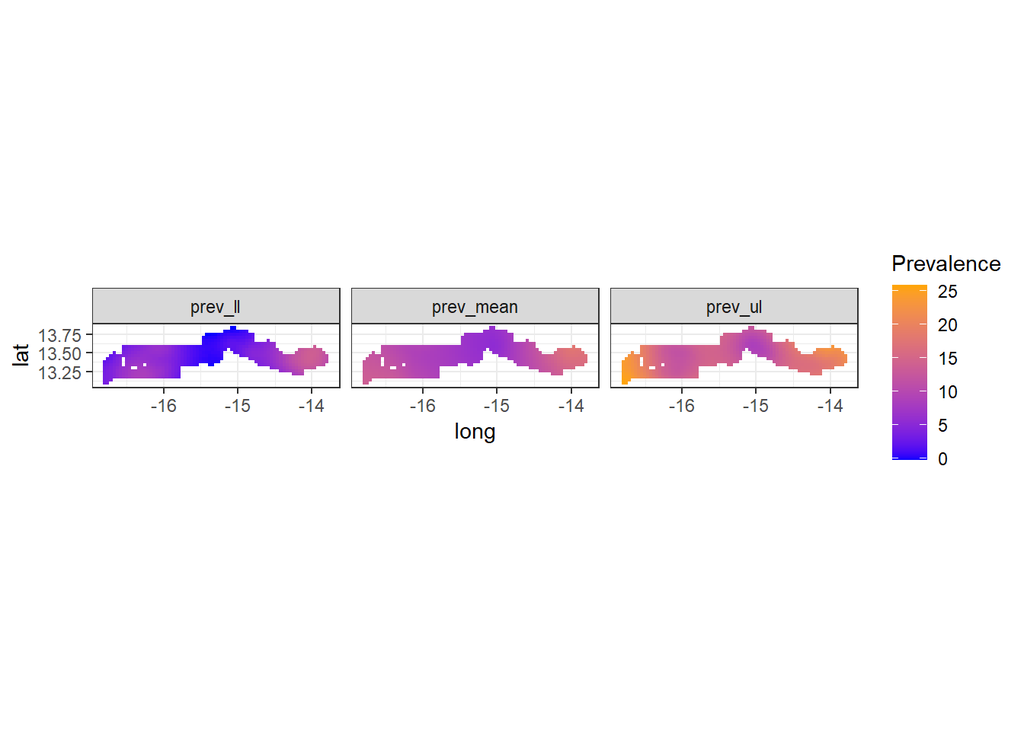

```r
#### Create maps of predicted prevalence and its bounds ####
# Obtain indices of the stack that correspond to the predictions
index <- inla.stack.index(stack = stk.full, tag = "pred")$data

prev_mean <- res4.1$summary.fitted.values[index,"mean"]
prev_ll <- res4.1$summary.fitted.values[index,"0.025quant"]
prev_ul <- res4.1$summary.fitted.values[index,"0.975quant"]

dpm <- rbind(
  data.frame(
    long = coop[, 1], lat = coop[, 2],
    value = prev_mean, variable = "prev_mean"
  ),
  data.frame(
    long = coop[, 1], lat = coop[, 2],
    value = prev_ll, variable = "prev_ll"
  ),
  data.frame(
    long = coop[, 1], lat = coop[, 2],
    value = prev_ul, variable = "prev_ul"
  )
)

dpm$variable <- as.factor(dpm$variable)

ggplot(dpm) + geom_tile(aes(long, lat, fill = value)) +
  facet_wrap(~variable, nrow = 1) +
  coord_fixed(ratio = 1) +
  scale_fill_gradient(
    name = "Prevalence",
    low = "blue", high = "orange"
  ) +
  theme_bw()
```

### Spatial + iid random effect (penalized complexity priors)

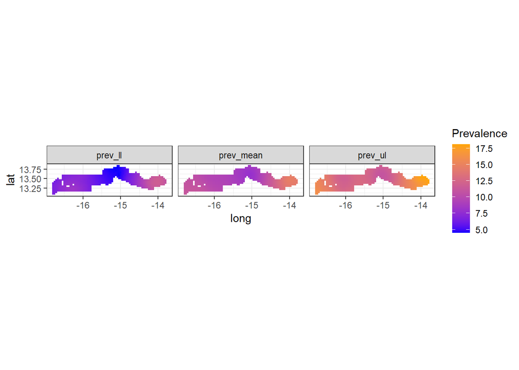

```r
#### Create maps of predicted prevalence and its bounds ####
# Obtain indices of the stack that correspond to the predictions
index <- inla.stack.index(stack = stk.full, tag = "pred")$data

prev_mean <- res4.2$summary.fitted.values[index,"mean"]
prev_ll <- res4.2$summary.fitted.values[index,"0.025quant"]
prev_ul <- res4.2$summary.fitted.values[index,"0.975quant"]

dpm <- rbind(
  data.frame(
    long = coop[, 1], lat = coop[, 2],
    value = prev_mean, variable = "prev_mean"
  ),
  data.frame(
    long = coop[, 1], lat = coop[, 2],
    value = prev_ll, variable = "prev_ll"
  ),
  data.frame(
    long = coop[, 1], lat = coop[, 2],
    value = prev_ul, variable = "prev_ul"
  )
)

dpm$variable <- as.factor(dpm$variable)

ggplot(dpm) + geom_tile(aes(long, lat, fill = value)) +
  facet_wrap(~variable, nrow = 1) +
  coord_fixed(ratio = 1) +
  scale_fill_gradient(
    name = "Prevalence",
    low = "blue", high = "orange"
  ) +
  theme_bw()
```

### Spatial + iid random effect + altitude covariate (default priors)

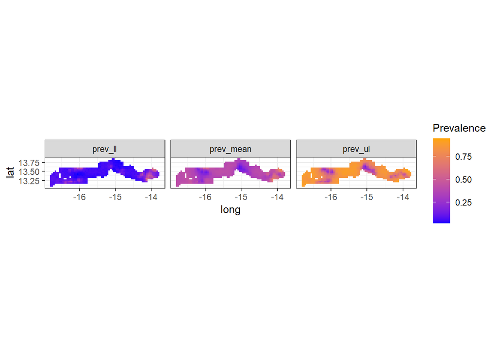

```r
#### Create maps of predicted prevalence and its bounds ####
# Obtain indices of the stack that correspond to the predictions
index <- inla.stack.index(stack = stk.full, tag = "pred")$data

prev_mean <- res5.1$summary.fitted.values[index,"mean"]
prev_ll <- res5.1$summary.fitted.values[index,"0.025quant"]
prev_ul <- res5.1$summary.fitted.values[index,"0.975quant"]

dpm <- rbind(
  data.frame(
    long = coop[, 1], lat = coop[, 2],
    value = prev_mean, variable = "prev_mean"
  ),
  data.frame(
    long = coop[, 1], lat = coop[, 2],
    value = prev_ll, variable = "prev_ll"
  ),
  data.frame(
    long = coop[, 1], lat = coop[, 2],
    value = prev_ul, variable = "prev_ul"
  )
)

dpm$variable <- as.factor(dpm$variable)

ggplot(dpm) + geom_tile(aes(long, lat, fill = value)) +
  facet_wrap(~variable, nrow = 1) +
  coord_fixed(ratio = 1) +
  scale_fill_gradient(
    name = "Prevalence",
    low = "blue", high = "orange"
  ) +
  theme_bw()
```

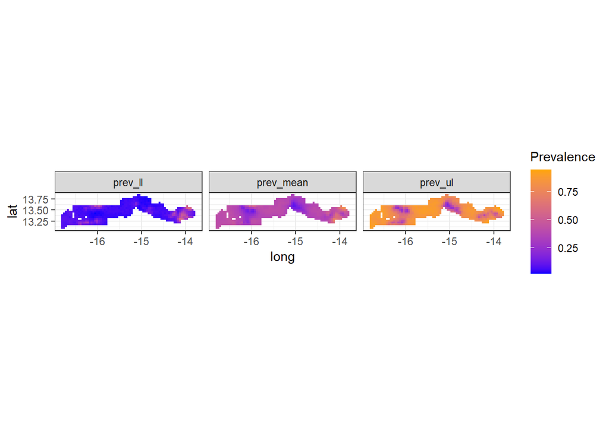

```r
#### Create maps of predicted prevalence and its bounds ####
# Obtain indices of the stack that correspond to the predictions
index <- inla.stack.index(stack = stk.full, tag = "pred")$data

prev_mean <- res5.1$summary.fitted.values[index,"mean"]
prev_ll <- res5.1$summary.fitted.values[index,"0.025quant"]
prev_ul <- res5.1$summary.fitted.values[index,"0.975quant"]

dpm <- rbind(
  data.frame(
    long = coop[, 1], lat = coop[, 2],
    value = prev_mean, variable = "prev_mean"
  ),
  data.frame(
    long = coop[, 1], lat = coop[, 2],
    value = prev_ll, variable = "prev_ll"
  ),
  data.frame(
    long = coop[, 1], lat = coop[, 2],
    value = prev_ul, variable = "prev_ul"
  )
)

dpm$variable <- as.factor(dpm$variable)

ggplot(dpm) + geom_tile(aes(long, lat, fill = value)) +
  facet_wrap(~variable, nrow = 1) +
  coord_fixed(ratio = 1) +
  scale_fill_gradient(
    name = "Prevalence",
    low = "blue", high = "orange"
  ) +
  theme_bw()
```

Multiple penalized complexity priors were tested and the penalized complexity priors below are used:

Prior.range: $Pr(\rho < 10) < 0.9$

These priors produced heatmaps where the spatial effect of the model is clearly visible and the prevalence bounds are not too extreme. Some other choices of priors yield heatmaps that were too extreme in either the predictions or the bound ranges. Therefore, the priors described above are used.

The predicted prevalence of the complete pool and hierarchical models have very erratic predictions, but their predicted high prevalence areas mostly appear on the west and east ends of Gambia.

The predicted prevalence of the spatial models differ in some areas; certain regions with low altitudes have clearly lower predicted prevalence in the spatial model that includes altitude as a covariate. Furthermore, both spatial models, regardless of priors, show higher predicted prevalence in the east end of Gambia, showing a clear spatial effect in the model for malaria prevalence.

# Spatial Residuals

For the models that include a spatial component, there is considerable change in residuals across different points on the map. Spatial variance is very high for the spatial models that do not include altitude as a covariate.

For models that do not include a spatial component, the observed prevalence is much higher than the mean predicted prevalence in eastern regions of Gambia, while the opposite is true for western regions of the country. This trend is apparent in all models that do not include a spatial component. This is indication for the need to include a spatial random effects term into the model.

## Complete pooling and altitude (no random effects)

```r
#### Create maps of observed prevalence - mean predicted prevalence ####
prev_mean <- res1$summary.fitted.values[,"mean"]

gambia.sf$prev_diff <- gambia.sf$prev - prev_mean

res1.diff <- tm_shape(gambia.sf) +
  tm_dots("prev_diff") +
  tm_layout(main.title = "Observed Prevalence - Predicted Prevalence")

tmap_mode("view")
res1.diff
```

[interactive chart not shown]

## Hierarchical random effect (iid) - (intercept only)

```r
#### Create maps of observed prevalence - mean predicted prevalence ####
prev_mean <- res2$summary.fitted.values[,"mean"]

gambia.sf$prev_diff <- gambia.sf$prev - prev_mean

res2.diff <- tm_shape(gambia.sf) +
  tm_dots("prev_diff") +
  tm_layout(main.title = "Observed Prevalence - Predicted Prevalence")

tmap_mode("view")
res2.diff
```

[interactive chart not shown]

## Hierarchical random effect (iid) + altitude covariate

```r
#### Create maps of observed prevalence - mean predicted prevalence ####
prev_mean <- res3$summary.fitted.values[,"mean"]

gambia.sf$prev_diff <- gambia.sf$prev - prev_mean

res3.diff <- tm_shape(gambia.sf) +
  tm_dots("prev_diff") +
  tm_layout(main.title = "Observed Prevalence - Predicted Prevalence")

tmap_mode("view")
res3.diff
```

[interactive chart not shown]

## Spatial + iid random effect (default priors)

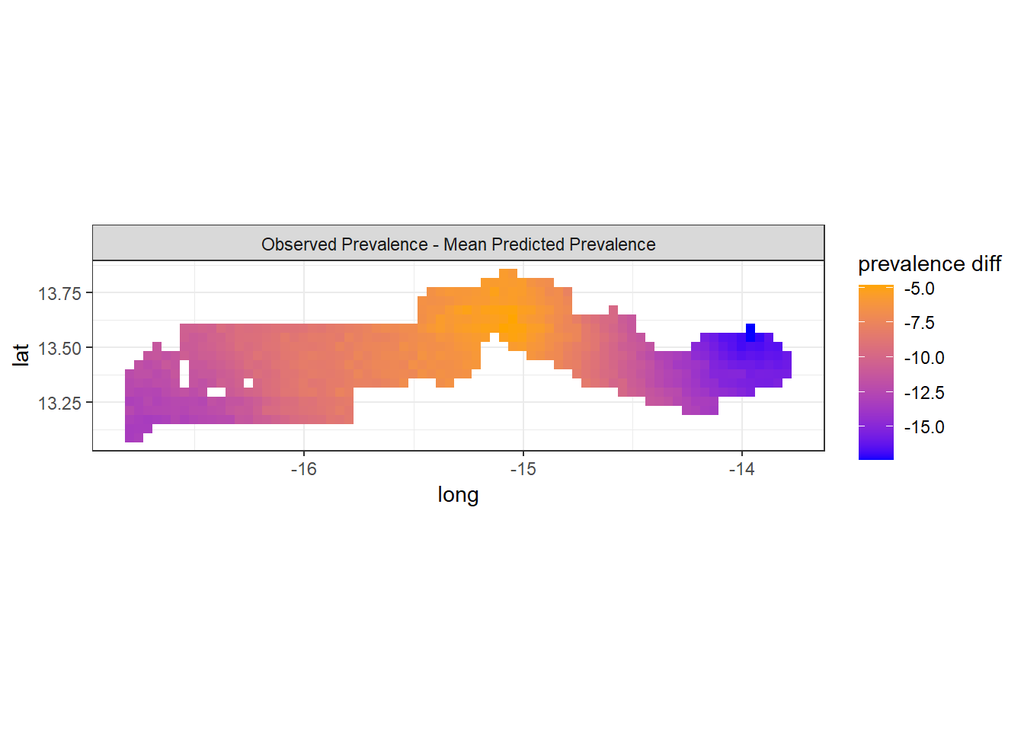

```r
#### Create maps of observed prevalence - mean predicted prevalence ####
# Obtain indices of the stack that correspond to the predictions
index <- inla.stack.index(stack = stk.full, tag = "pred")$data

prev_mean <- res4.1$summary.fitted.values[index,"mean"]

dpm <- rbind(
  data.frame(
    long = coop[, 1], lat = coop[, 2],
    value = gambia.sf$prev - prev_mean,
    variable = "Observed Prevalence - Mean Predicted Prevalence"
  )
)

dpm$variable <- as.factor(dpm$variable)

ggplot(dpm) + geom_tile(aes(long, lat, fill = value)) +
  facet_wrap(~variable, nrow = 1) +
  coord_fixed(ratio = 1) +
  scale_fill_gradient(
    name = "prevalence diff",
    low = "blue", high = "orange"
  ) +
  theme_bw()
```

## Spatial + iid random effect (penalized complexity priors)

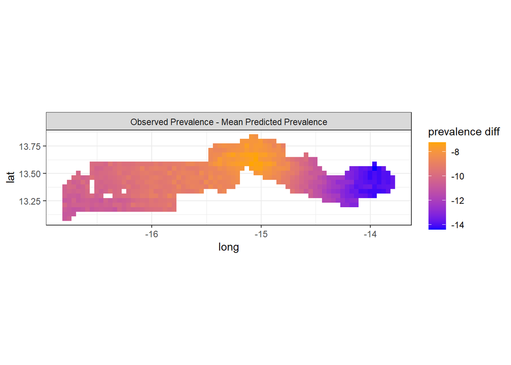

```r
#### Create maps of observed prevalence - mean predicted prevalence ####
# Obtain indices of the stack that correspond to the predictions
index <- inla.stack.index(stack = stk.full, tag = "pred")$data

prev_mean <- res4.2$summary.fitted.values[index,"mean"]

dpm <- rbind(
  data.frame(
    long = coop[, 1], lat = coop[, 2],
    value = gambia.sf$prev - prev_mean,
    variable = "Observed Prevalence - Mean Predicted Prevalence"
  )
)

dpm$variable <- as.factor(dpm$variable)

ggplot(dpm) + geom_tile(aes(long, lat, fill = value)) +
  facet_wrap(~variable, nrow = 1) +
  coord_fixed(ratio = 1) +
  scale_fill_gradient(
    name = "prevalence diff",
    low = "blue", high = "orange"
  ) +
  theme_bw()
```

## Spatial + iid random effect + altitude covariate (default priors)

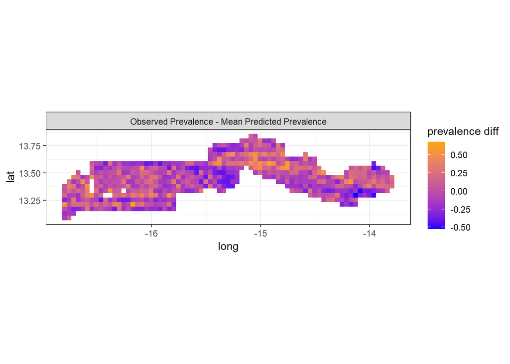

```r
#### Create maps of observed prevalence - mean predicted prevalence ####
# Obtain indices of the stack that correspond to the predictions
index <- inla.stack.index(stack = stk.full, tag = "pred")$data

prev_mean <- res5.1$summary.fitted.values[index,"mean"]

dpm <- rbind(
  data.frame(
    long = coop[, 1], lat = coop[, 2],
    value = gambia.sf$prev - prev_mean,
    variable = "Observed Prevalence - Mean Predicted Prevalence"
  )
)

dpm$variable <- as.factor(dpm$variable)

ggplot(dpm) + geom_tile(aes(long, lat, fill = value)) +
  facet_wrap(~variable, nrow = 1) +
  coord_fixed(ratio = 1) +
  scale_fill_gradient(
    name = "prevalence diff",
    low = "blue", high = "orange"
  ) +
  theme_bw()
```

## Spatial + iid random effect + altitude covariate (penalized complexity priors)

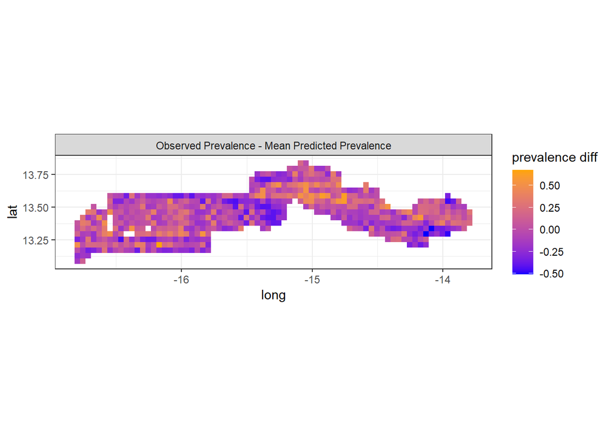

```r
#### Create maps of observed prevalence - mean predicted prevalence ####
# Obtain indices of the stack that correspond to the predictions
index <- inla.stack.index(stack = stk.full, tag = "pred")$data

prev_mean <- res5.2$summary.fitted.values[index,"mean"]

dpm <- rbind(
  data.frame(
    long = coop[, 1], lat = coop[, 2],
    value = gambia.sf$prev - prev_mean,
    variable = "Observed Prevalence - Mean Predicted Prevalence"
  )
)

dpm$variable <- as.factor(dpm$variable)

ggplot(dpm) + geom_tile(aes(long, lat, fill = value)) +
  facet_wrap(~variable, nrow = 1) +
  coord_fixed(ratio = 1) +
  scale_fill_gradient(
    name = "prevalence diff",
    low = "blue", high = "orange"
  ) +
  theme_bw()
```

# Results + PIT histograms

```r
#### Organize Results in a Table: Estimates and Credible Intervals ####
##### Complete pooling and altitude (no random effects) #####
table.res1 <- data.frame(LowerLimit = res1$summary.fixed$`0.025quant`,
                       UpperLimit = res1$summary.fixed$`0.975quant`,
                       Estimate = res1$summary.fixed$mean)
rownames(table.res1)<- c("Model 1 Intercept","Model 1 Covariate")

##### Hierarchical random effect (iid) - (intercept only) #####
table.res2 <- data.frame(LowerLimit = res2$summary.fixed$`0.025quant`,
                       UpperLimit = res2$summary.fixed$`0.975quant`,
                       Estimate = res2$summary.fixed$mean)
rownames(table.res2)<- c("Model 2 Intercept")

##### Hierarchical random effect (iid) + altitude covariate #####
table.res3 <- data.frame(LowerLimit = res3$summary.fixed$`0.025quant`,
                       UpperLimit = res3$summary.fixed$`0.975quant`,
                       Estimate = res3$summary.fixed$mean)
rownames(table.res3)<- c("Model 3 Intercept","Model 3 Covariate")

##### Spatial + iid random effect (default priors) #####
table.res4.1 <- data.frame(LowerLimit = res4.1$summary.fixed$`0.025quant`,
                       UpperLimit = res4.1$summary.fixed$`0.975quant`,
                       Estimate = res4.1$summary.fixed$mean)
rownames(table.res4.1)<- c("Model 4.1 Intercept")

##### Spatial + iid random effect (pc priors) #####
table.res4.2 <- data.frame(LowerLimit = res4.2$summary.fixed$`0.025quant`,
                       UpperLimit = res4.2$summary.fixed$`0.975quant`,
                       Estimate = res4.2$summary.fixed$mean)
rownames(table.res4.2)<- c("Model 4.2 Intercept")

##### Spatial + iid random effect + altitude covariate (default priors) #####
table.res5.1 <- data.frame(LowerLimit = res5.1$summary.fixed$`0.025quant`,
                       UpperLimit = res5.1$summary.fixed$`0.975quant`,
                       Estimate = res5.1$summary.fixed$mean)
rownames(table.res5.1)<- c("Model 5.1 Intercept","Model 5.1 Covariate")

##### Spatial + iid random effect + altitude covariate (pc priors) #####
table.res5.2 <- data.frame(LowerLimit = res5.2$summary.fixed$`0.025quant`,
                       UpperLimit = res5.2$summary.fixed$`0.975quant`,
                       Estimate = res5.2$summary.fixed$mean)
rownames(table.res5.2)<- c("Model 5.2 Intercept","Model 5.2 Covariate")

##### Merge all tables #####
table.res <- bind_rows(table.res1, table.res2, table.res3, table.res4.1,
                       table.res4.2, table.res5.1, table.res5.2)
table.res %>%
  kable(
    caption = "Parameter Estimates and 95% Credible Intervals For All 7 Models",
    col.names = c("Lower Bound", "Upper Bound", "Estimate"),
    row.names = TRUE,
    digits = 4,
    booktabs = TRUE
  )
```

Parameter Estimates and 95% Credible Intervals For All 7 Models

|  | Lower Bound | Upper Bound | Estimate |
| --- | --- | --- | --- |
| Model 1 Intercept | 0.1458 | 0.3964 | 0.2711 |
| Model 1 Covariate | 0.0000 | 0.0100 | 0.0050 |
| Model 2 Intercept | 0.3296 | 0.4397 | 0.3847 |
| Model 3 Intercept | 0.1270 | 0.3872 | 0.2568 |
| Model 3 Covariate | -0.0003 | 0.0119 | 0.0057 |
| Model 4.1 Intercept | 8.4591 | 13.7965 | 10.9674 |
| Model 4.2 Intercept | 9.2747 | 12.5639 | 10.9221 |
| Model 5.1 Intercept | -1.2223 | 0.8401 | -0.3228 |
| Model 5.1 Covariate | -0.0297 | 0.0203 | -0.0055 |
| Model 5.2 Intercept | -1.0797 | 0.7349 | -0.2395 |
| Model 5.2 Covariate | -0.0286 | 0.0133 | -0.0077 |

```r
#### Organize Results in a Table: Sum of Log(CPO) ####
sum_cpo1 <- sum(log(res1$cpo$cpo))
sum_cpo2 <- sum(log(res2$cpo$cpo))
sum_cpo3 <- sum(log(res3$cpo$cpo))
sum_cpo4.1 <- sum(log(res4.1$cpo$cpo[1:65]))
sum_cpo4.2 <- sum(log(res4.2$cpo$cpo[1:65]))
sum_cpo5.1 <- sum(log(res5.1$cpo$cpo[1:65]))
sum_cpo5.2 <- sum(log(res5.2$cpo$cpo[1:65]))

sum_cpo <- t(data.frame(sum_cpo1, sum_cpo2, sum_cpo3, sum_cpo4.1, sum_cpo4.2,
                        sum_cpo5.1, sum_cpo5.2))
rownames(sum_cpo) <- c("Model 1", "Model 2", "Model 3", "Model 4.1",
                       "Model 4.2", "Model 5.1", "Model 5.2")

sum_cpo %>%
  kable(
    caption = "Sum of Log(CPO) for All 7 Models",
    col.names = "Sum of Log(CPO)",
    row.names = TRUE,
  )
```

Sum of Log(CPO) for All 7 Models

|  | Sum of Log(CPO) |
| --- | --- |
| Model 1 | 3.981774 |
| Model 2 | 101.447830 |
| Model 3 | 3.032147 |
| Model 4.1 | -201.638515 |
| Model 4.2 | -204.314479 |
| Model 5.1 | -291.705484 |
| Model 5.2 | -267.852073 |

A smaller value of $-\sum log(CPO)$ points to a better model fit. Therefore, Model 2, Hierarchical random effect (iid) - (intercept only), is the model with the best fit. This is in line with the difference between observed prevalence and predicted prevalence as plotted in the Spatial Residuals section. Note that the model deemed to be the best fit via CPO does not include a spatial component, however we observed in previous segments that a spatial random effect seems to be present in the data. Therefore, low CPO may simply be a result of the model fitting the dataset well and is not indicative of the model’s performance for data on a larger scale.

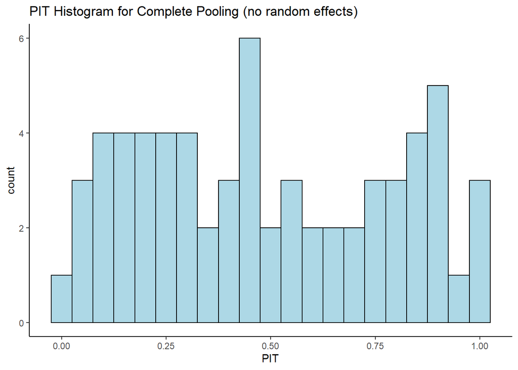

```r
#### Plot Histogram of the PIT values ####
##### Model 1: Complete pooling and altitude (no random effects) #####
pit1 <- data.frame(PIT = res1$cpo$pit)

ggplot(data = pit1, aes(x=PIT)) +
  geom_histogram(binwidth=0.05, color="black", fill="lightblue") +
  theme_classic() +
  labs(title = "PIT Histogram for Complete Pooling (no random effects)")
```

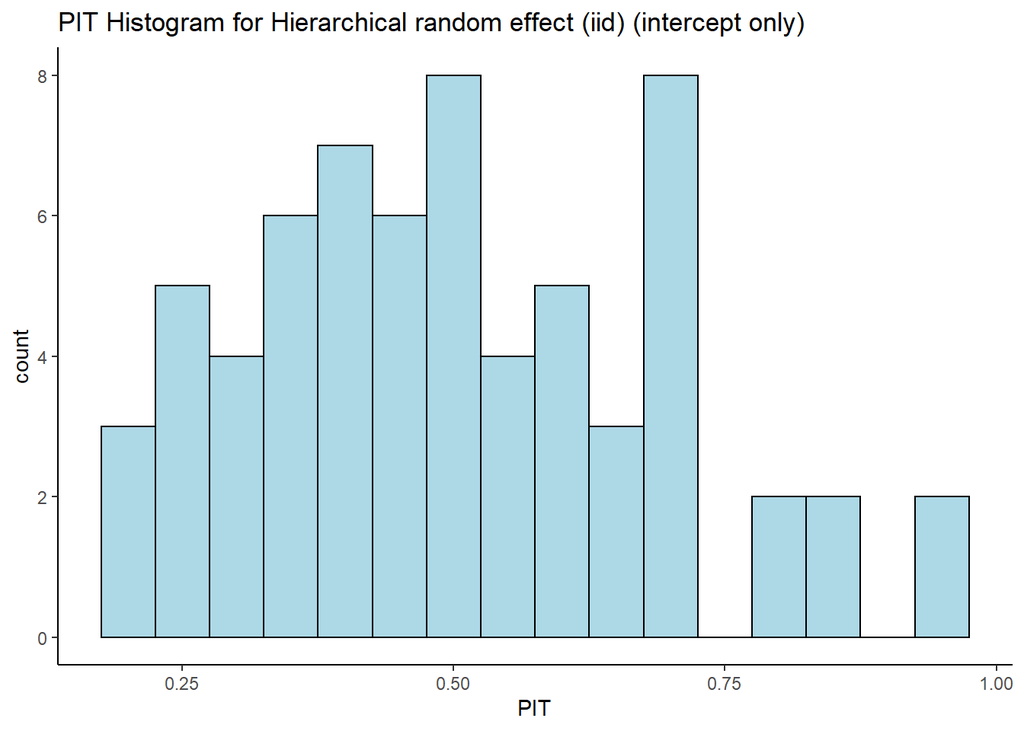

```r
##### Model 2: Hierarchical random effect (iid) - (intercept only) #####
pit2 <- data.frame(PIT = res2$cpo$pit)

ggplot(data = pit2, aes(x=PIT)) +
  geom_histogram(binwidth=0.05, color="black", fill="lightblue") +
  labs(title="PIT Histogram for Hierarchical random effect (iid) (intercept only)") +
  theme_classic()
```

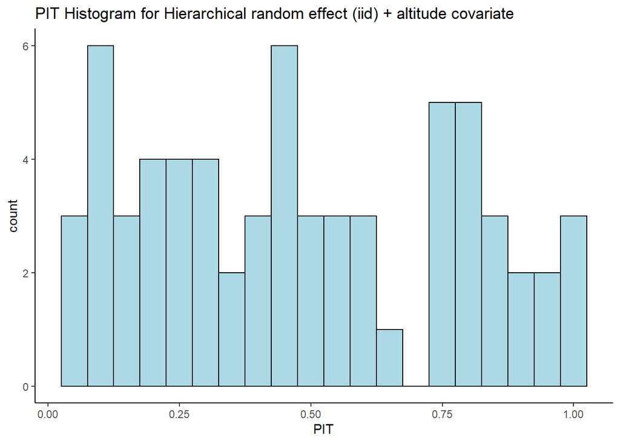

```r
##### Model 3: Hierarchical random effect (iid) + altitude covariate #####
pit3 <- data.frame(PIT = res3$cpo$pit)

ggplot(data = pit3, aes(x=PIT)) +
  geom_histogram(binwidth=0.05, color="black", fill="lightblue") +
  labs(title="PIT Histogram for Hierarchical random effect (iid) + altitude covariate") +
  theme_classic()
```

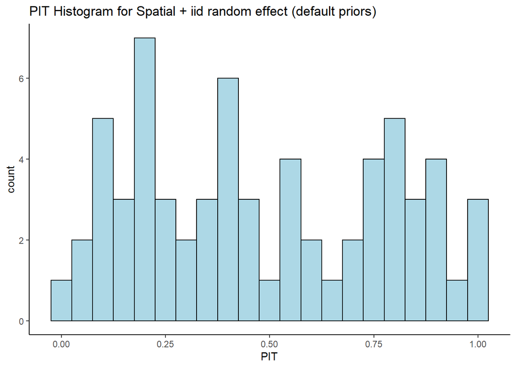

```r
##### Model 4.1: Spatial + iid random effect (default priors) #####
pit4.1 <- data.frame(PIT = res4.1$cpo$pit[1:65])

ggplot(data = pit4.1, aes(x=PIT)) +
  geom_histogram(binwidth=0.05, color="black", fill="lightblue") +
  labs(title="PIT Histogram for Spatial + iid random effect (default priors)") +
  theme_classic()
```

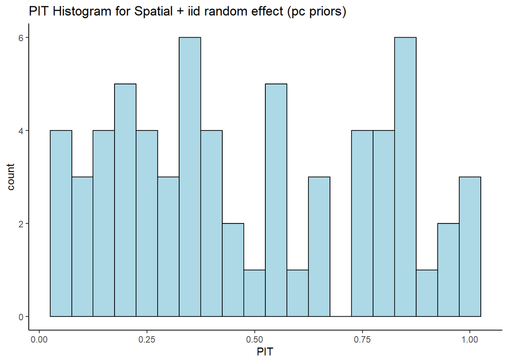

```r
##### Model 4.2: Spatial + iid random effect (pc priors) #####
pit4.2 <- data.frame(PIT = res4.2$cpo$pit[1:65])

ggplot(data = pit4.2, aes(x=PIT)) +
  geom_histogram(binwidth=0.05, color="black", fill="lightblue") +
  labs(title="PIT Histogram for Spatial + iid random effect (pc priors)") +
  theme_classic()
```

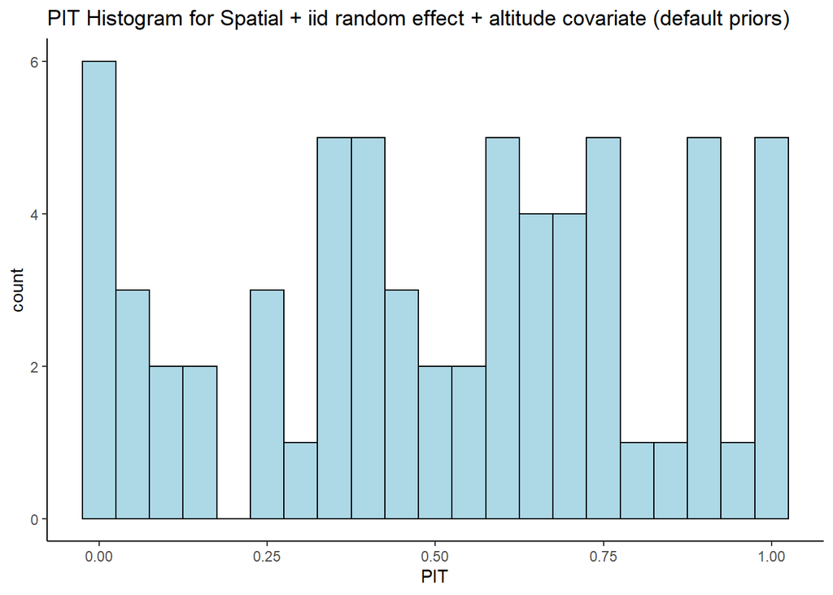

```r
##### Model 5.1: Spatial + iid random effect + altitude covariate (default priors) #####
pit5.1 <- data.frame(PIT = res5.1$cpo$pit[1:65])

ggplot(data = pit5.1, aes(x=PIT)) +
  geom_histogram(binwidth=0.05, color="black", fill="lightblue") +
  labs(title="PIT Histogram for Spatial + iid random effect + altitude covariate (default priors)") +
  theme_classic()
```

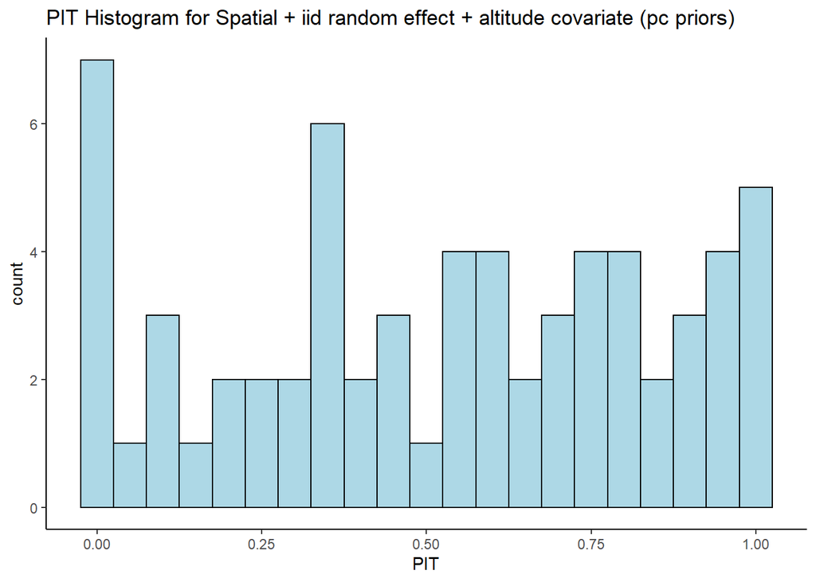

```r
##### Model 5.2: Spatial + iid random effect + altitude covariate (pc priors) #####
pit5.2 <- data.frame(PIT = res5.2$cpo$pit[1:65])

ggplot(data = pit5.2, aes(x=PIT)) +
  geom_histogram(binwidth=0.05, color="black", fill="lightblue") +
  labs(title="PIT Histogram for Spatial + iid random effect + altitude covariate (pc priors)") +
  theme_classic()
```

# Spatial K-fold CV

```r
#### Perform 4-fold CV ####
##### Parition the points based on Coordinates #####
# partition for Kerewan
part1 <- filter(gambia.sf, x > 363790 & x < 397080 & y > 1490500 & y < 1502000)
# partition for Brikama
part2 <- filter(gambia.sf, x > 349600 & x < 390500 & y > 1458000 & y < 1466500)
# partition for JanJan Bureh
part3 <- filter(gambia.sf, x > 486500 & x < 524000 & y > 1485000 & y < 1515000)
# partition for Basse
part4 <- filter(gambia.sf, x > 572000 & x < 622500 & y > 1467000 & y < 1500000)

tm_shape(part1) + tm_dots("prev", col = "red") +
  tm_layout(title = "Kerewan Partition")
```

[interactive chart not shown]

```r
tm_shape(part2) + tm_dots("prev", col = "lightblue") +
  tm_layout(title = "Brikama Partition")
```

[interactive chart not shown]

```r
tm_shape(part3) + tm_dots("prev", col = "green") +
  tm_layout(title = "JanJan Bureh Partition")
```

[interactive chart not shown]

```r
tm_shape(part4) + tm_dots("prev", col = "yellow") +
  tm_layout(title = "Basse Partition")
```

[interactive chart not shown]

```r
# S is sample size
S <- nrow(gambia.sf)

##### Model 1: Complete pooling and altitude (no random effects) #####
## First time
# To predict points in Kerewan region, set the prev of points in the said region
# to NA
N <- nrow(part1)
pred1 <- gambia.sf %>%
  filter(x > 363790 & x < 397080 & y > 1490500 & y < 1502000) %>%
  mutate(prev = NA) %>%
  bind_rows(part2,part3,part4)

res1.1 <- inla(formula1, data = pred1,
            control.predictor = list(compute = TRUE))

pred_mean1.1 <- res1.1$summary.fitted.values[1:N, "mean"]
# Calculate (1/S) (sum(y_i - \hat(y_i))^2)
sta1.1 <- sum((part1$prev - pred_mean1.1*N)^2)/S

## Second Time
N <- nrow(part2)
pred2 <- gambia.sf %>%
  filter(x > 349600 & x < 390500 & y > 1458000 & y < 1466500) %>%
  mutate(prev = NA) %>%
  bind_rows(part1,part3,part4)

res1.2 <- inla(formula1, data = pred2,
            control.predictor = list(compute = TRUE))

pred_mean1.2 <- res1.2$summary.fitted.values[1:N, "mean"]
# Calculate (1/S) (sum(y_i - \hat(y_i))^2)
sta1.2 <- sum((part2$prev - pred_mean1.2*N)^2)/S

## Third time
N <- nrow(part3)
pred3 <- gambia.sf %>%
  filter(x > 486500 & x < 524000 & y > 1485000 & y < 1515000) %>%
  mutate(prev = NA) %>%
  bind_rows(part1,part2,part4)

res1.3 <- inla(formula1, data = pred3,
            control.predictor = list(compute = TRUE))

pred_mean1.3 <- res1.3$summary.fitted.values[1:N, "mean"]
# Calculate (1/S) (sum(y_i - \hat(y_i))^2)
sta1.3 <- sum((part3$prev - pred_mean1.3*N)^2)/S

## Fourth time
N <- nrow(part4)
pred4 <- gambia.sf %>%
  filter(x > 572000 & x < 622500 & y > 1467000 & y < 1500000) %>%
  mutate(prev = NA) %>%
  bind_rows(part1,part2,part3)

res1.4 <- inla(formula1, data = pred4,
            control.predictor = list(compute = TRUE))

pred_mean1.4 <- res1.4$summary.fitted.values[1:N, "mean"]
# Calculate (1/S) (sum(y_i - \hat(y_i))^2)
sta1.4 <- sum((part3$prev - pred_mean1.4*N)^2)/S

## Create a table for the Statistic
sta1 <- data.frame(sta1 = sta1.1, sta2 = sta1.2,
                   sta3 = sta1.3, sta4 = sta1.4)

##### Model 2: Hierarchical random effect (iid) - (intercept only) #####
## First time
N <- nrow(part1)

gambia.sf$idu <- 1:nrow(gambia.sf)
gambia.sf$idv <- 1:nrow(gambia.sf)

pred1 <- gambia.sf %>%
  filter(x > 363790 & x < 397080 & y > 1490500 & y < 1502000) %>%
  mutate(prev = NA) %>%
  bind_rows(part2,part3,part4)


res2.1 <- inla(formula2, data = pred1,
            control.predictor = list(compute = TRUE),
            control.compute = list(cpo=TRUE))

pred_mean2.1 <- res2.1$summary.fitted.values[1:N, "mean"]
# Calculate (1/S) (sum(y_i - \hat(y_i))^2)
sta2.1 <- sum((part1$prev - pred_mean2.1*N)^2)/S

## Second Time
N <- nrow(part2)
pred2 <- gambia.sf %>%
  filter(x > 349600 & x < 390500 & y > 1458000 & y < 1466500) %>%
  mutate(prev = NA) %>%
  bind_rows(part1,part3,part4)

res2.2 <- inla(formula2, data = pred2,
            control.predictor = list(compute = TRUE),
            control.compute = list(cpo=TRUE))

pred_mean2.2 <- res2.2$summary.fitted.values[1:N, "mean"]
# Calculate (1/S) (sum(y_i - \hat(y_i))^2)
sta2.2 <- sum((part2$prev - pred_mean2.2*N)^2)/S

## Third time
N <- nrow(part3)
pred3 <- gambia.sf %>%
  filter(x > 486500 & x < 524000 & y > 1485000 & y < 1515000) %>%
  mutate(prev = NA) %>%
  bind_rows(part1,part2,part4)

res2.3 <- inla(formula2, data = pred3,
            control.predictor = list(compute = TRUE),
            control.compute = list(cpo=TRUE))

pred_mean2.3 <- res2.3$summary.fitted.values[1:N, "mean"]
# Calculate (1/S) (sum(y_i - \hat(y_i))^2)
sta2.3 <- sum((part3$prev - pred_mean2.3*N)^2)/S

## Fourth time
N <- nrow(part4)
pred4 <- gambia.sf %>%
  filter(x > 572000 & x < 622500 & y > 1467000 & y < 1500000) %>%
  mutate(prev = NA) %>%
  bind_rows(part1,part2,part3)

res2.4 <- inla(formula2, data = pred4,
            control.predictor = list(compute = TRUE),
            control.compute = list(cpo=TRUE))

pred_mean2.4 <- res2.4$summary.fitted.values[1:N, "mean"]
# Calculate (1/S) (sum(y_i - \hat(y_i))^2)
sta2.4 <- sum((part3$prev - pred_mean2.4*N)^2)/S

## Create a table for the Statistic
sta2 <- data.frame(sta1 = sta2.1, sta2 = sta2.2,
                   sta3 = sta2.3, sta4 = sta2.4)

##### Model 3: Hierarchical random effect (iid) + altitude covariate #####
## First time
N <- nrow(part1)

pred1 <- gambia.sf %>%
  filter(x > 363790 & x < 397080 & y > 1490500 & y < 1502000) %>%
  mutate(prev = NA) %>%
  bind_rows(part2,part3,part4)

res3.1 <- inla(formula3, data = pred1,
            control.predictor = list(compute = TRUE))

pred_mean3.1 <- res3.1$summary.fitted.values[1:N, "mean"]
# Calculate (1/S) (sum(y_i - \hat(y_i))^2)
sta3.1 <- sum((part1$prev - pred_mean3.1*N)^2)/S

## Second Time
N <- nrow(part2)
pred2 <- gambia.sf %>%
  filter(x > 349600 & x < 390500 & y > 1458000 & y < 1466500) %>%
  mutate(prev = NA) %>%
  bind_rows(part1,part3,part4)

res3.2 <- inla(formula3, data = pred2,
            control.predictor = list(compute = TRUE))

pred_mean3.2 <- res3.2$summary.fitted.values[1:N, "mean"]
# Calculate (1/S) (sum(y_i - \hat(y_i))^2)
sta3.2 <- sum((part2$prev - pred_mean3.2*N)^2)/S

## Third time
N <- nrow(part3)
pred3 <- gambia.sf %>%
  filter(x > 486500 & x < 524000 & y > 1485000 & y < 1515000) %>%
  mutate(prev = NA) %>%
  bind_rows(part1,part2,part4)

res3.3 <- inla(formula3, data = pred3,
            control.predictor = list(compute = TRUE))

pred_mean3.3 <- res3.3$summary.fitted.values[1:N, "mean"]
# Calculate (1/S) (sum(y_i - \hat(y_i))^2)
sta3.3 <- sum((part3$prev - pred_mean3.3*N)^2)/S

## Fourth time
N <- nrow(part4)
pred4 <- gambia.sf %>%
  filter(x > 572000 & x < 622500 & y > 1467000 & y < 1500000) %>%
  mutate(prev = NA) %>%
  bind_rows(part1,part2,part3)

res3.4 <- inla(formula3, data = pred4,
            control.predictor = list(compute = TRUE))

pred_mean3.4 <- res3.4$summary.fitted.values[1:N, "mean"]
# Calculate (1/S) (sum(y_i - \hat(y_i))^2)
sta3.4 <- sum((part3$prev - pred_mean3.4*N)^2)/S

## Create a table for the Statistic
sta3 <- data.frame(sta1 = sta2.1, sta2 = sta2.2,
                   sta3 = sta2.3, sta4 = sta2.4)
```

```r
##### Model 4.1: Spatial + iid random effect (default priors) #####
###### Parition the points based on Coordinates ######
# partition for Kerewan
part1 <- filter(d, x > 363790 & x < 397080 & y > 1490500 & y < 1502000)
# partition for Brikama
part2 <- filter(d, x > 349600 & x < 390500 & y > 1458000 & y < 1466500)
# partition for JanJan Bureh
part3 <- filter(d, x > 486500 & x < 524000 & y > 1485000 & y < 1515000)
# partition for Basse
part4 <- filter(d, x > 572000 & x < 622500 & y > 1467000 & y < 1500000)

###### First Time ######
N <- nrow(part1)

pred1 <- d %>%
  filter(x > 363790 & x < 397080 & y > 1490500 & y < 1502000) %>%
  mutate(prev = NA) %>%
  bind_rows(part2,part3,part4)

## Mesh Construction
# Code modified from MalariaPrevalence.Rmd in Lab 7
coo <- cbind(pred1$long, pred1$lat)
mesh <- inla.mesh.2d(
  loc = coo, max.edge = c(0.1, 5),
  cutoff = 0.01
)

## Construct "A" projection matrices
spde <- inla.spde2.matern(mesh = mesh, alpha = 2, constr = TRUE)


indexs <- inla.spde.make.index("s", spde$n.spde)
A <- inla.spde.make.A(mesh = mesh, loc = coo)

## Prediction data
dp <- rasterToPoints(r)
ra <- aggregate(r, fact = 5, fun = mean)
dp <- rasterToPoints(ra)
coop <- dp[, c("x", "y")]
Ap <- inla.spde.make.A(mesh = mesh, loc = coop)

## stack for estimation stk.e
stk.e <- inla.stack(
  tag = "est",
  data = list(y = pred1$positive, numtrials = pred1$total),
  A = list(1, A),
  effects = list(data.frame(b0 = 1, altitude = pred1$alt), s = indexs)
)

# stack for prediction stk.p
stk.p <- inla.stack(
  tag = "pred",
  data = list(y = NA, numtrials = NA),
  A = list(1, Ap),
  effects = list(data.frame(b0 = 1, altitude = dp[, 3]),
    s = indexs
  )
)

# stk.full has stk.e and stk.p
stk.full <- inla.stack(stk.e, stk.p)

## Model formula and inla call
res4.1.1 <- inla(formula4.1,
  data = inla.stack.data(stk.full),
  control.predictor = list(
    compute = TRUE,
    A = inla.stack.A(stk.full)
  )
)

pred_mean4.1.1 <- res4.1.1$summary.fitted.values[1:N, "mean"]
# Calculate (1/S) (sum(y_i - \hat(y_i))^2)
sta4.1.1 <- sum((part1$prev - pred_mean4.1.1*N)^2)/S

###### Second Time ######
N <- nrow(part2)
pred2 <- d %>%
  filter(x > 349600 & x < 390500 & y > 1458000 & y < 1466500) %>%
  mutate(prev = NA) %>%
  bind_rows(part1,part3,part4)

## Mesh Construction
# Code modified from MalariaPrevalence.Rmd in Lab 7
coo <- cbind(pred2$long, pred2$lat)
mesh <- inla.mesh.2d(
  loc = coo, max.edge = c(0.1, 5),
  cutoff = 0.01
)

## Construct "A" projection matrices
spde <- inla.spde2.matern(mesh = mesh, alpha = 2, constr = TRUE)


indexs <- inla.spde.make.index("s", spde$n.spde)
A <- inla.spde.make.A(mesh = mesh, loc = coo)

## Prediction data
dp <- rasterToPoints(r)
ra <- aggregate(r, fact = 5, fun = mean)
dp <- rasterToPoints(ra)
coop <- dp[, c("x", "y")]
Ap <- inla.spde.make.A(mesh = mesh, loc = coop)

## stack for estimation stk.e
stk.e <- inla.stack(
  tag = "est",
  data = list(y = pred2$positive, numtrials = pred2$total),
  A = list(1, A),
  effects = list(data.frame(b0 = 1, altitude = pred2$alt), s = indexs)
)

# stack for prediction stk.p
stk.p <- inla.stack(
  tag = "pred",
  data = list(y = NA, numtrials = NA),
  A = list(1, Ap),
  effects = list(data.frame(b0 = 1, altitude = dp[, 3]),
    s = indexs
  )
)

# stk.full has stk.e and stk.p
stk.full <- inla.stack(stk.e, stk.p)

## Model formula and inla call
res4.1.2 <- inla(formula4.1,
  data = inla.stack.data(stk.full),
  control.predictor = list(
    compute = TRUE,
    A = inla.stack.A(stk.full)
  )
)

pred_mean4.1.2 <- res4.1.2$summary.fitted.values[1:N, "mean"]
# Calculate (1/S) (sum(y_i - \hat(y_i))^2)
sta4.1.2 <- sum((part2$prev - pred_mean4.1.2*N)^2)/S

###### Third Time ######
N <- nrow(part3)
pred3 <- d %>%
  filter(x > 486500 & x < 524000 & y > 1485000 & y < 1515000) %>%
  mutate(prev = NA) %>%
  bind_rows(part1,part2,part4)

## Mesh Construction
# Code modified from MalariaPrevalence.Rmd in Lab 7
coo <- cbind(pred3$long, pred3$lat)
mesh <- inla.mesh.2d(
  loc = coo, max.edge = c(0.1, 5),
  cutoff = 0.01
)

## Construct "A" projection matrices
spde <- inla.spde2.matern(mesh = mesh, alpha = 2, constr = TRUE)

indexs <- inla.spde.make.index("s", spde$n.spde)
A <- inla.spde.make.A(mesh = mesh, loc = coo)

## Prediction data
dp <- rasterToPoints(r)
ra <- aggregate(r, fact = 5, fun = mean)
dp <- rasterToPoints(ra)
coop <- dp[, c("x", "y")]
Ap <- inla.spde.make.A(mesh = mesh, loc = coop)

## stack for estimation stk.e
stk.e <- inla.stack(
  tag = "est",
  data = list(y = pred3$positive, numtrials = pred3$total),
  A = list(1, A),
  effects = list(data.frame(b0 = 1, altitude = pred3$alt), s = indexs)
)

# stack for prediction stk.p
stk.p <- inla.stack(
  tag = "pred",
  data = list(y = NA, numtrials = NA),
  A = list(1, Ap),
  effects = list(data.frame(b0 = 1, altitude = dp[, 3]),
    s = indexs
  )
)

# stk.full has stk.e and stk.p
stk.full <- inla.stack(stk.e, stk.p)

## Model formula and inla call
res4.1.3 <- inla(formula4.1,
  data = inla.stack.data(stk.full),
  control.predictor = list(
    compute = TRUE,
    A = inla.stack.A(stk.full)
  )
)

pred_mean4.1.3 <- res4.1.3$summary.fitted.values[1:N, "mean"]
# Calculate (1/S) (sum(y_i - \hat(y_i))^2)
sta4.1.3 <- sum((part3$prev - pred_mean4.1.3*N)^2)/S

###### Fourth Time ######
## Fourth time
N <- nrow(part4)
pred4 <- d %>%
  filter(x > 572000 & x < 622500 & y > 1467000 & y < 1500000) %>%
  mutate(prev = NA) %>%
  bind_rows(part1,part2,part3)

## Mesh Construction
# Code modified from MalariaPrevalence.Rmd in Lab 7
coo <- cbind(pred4$long, pred4$lat)
mesh <- inla.mesh.2d(
  loc = coo, max.edge = c(0.1, 5),
  cutoff = 0.01
)

## Construct "A" projection matrices
spde <- inla.spde2.matern(mesh = mesh, alpha = 2, constr = TRUE)

indexs <- inla.spde.make.index("s", spde$n.spde)
A <- inla.spde.make.A(mesh = mesh, loc = coo)

## Prediction data
dp <- rasterToPoints(r)
ra <- aggregate(r, fact = 5, fun = mean)
dp <- rasterToPoints(ra)
coop <- dp[, c("x", "y")]
Ap <- inla.spde.make.A(mesh = mesh, loc = coop)
```

```r
## stack for estimation stk.e
stk.e <- inla.stack(
  tag = "est",
  data = list(y = pred4$positive, numtrials = pred4$total),
  A = list(1, A),
  effects = list(data.frame(b0 = 1, altitude = pred4$alt), s = indexs)
)

# stack for prediction stk.p
stk.p <- inla.stack(
  tag = "pred",
  data = list(y = NA, numtrials = NA),
  A = list(1, Ap),
  effects = list(data.frame(b0 = 1, altitude = dp[, 3]),
    s = indexs
  )
)

# stk.full has stk.e and stk.p
stk.full <- inla.stack(stk.e, stk.p)

## Model formula and inla call
res4.1.4 <- inla(formula4.1,
  data = inla.stack.data(stk.full),
  control.predictor = list(
    compute = TRUE,
    A = inla.stack.A(stk.full)
  )
)

pred_mean4.1.4 <- res4.1.4$summary.fitted.values[1:N, "mean"]
# Calculate (1/S) (sum(y_i - \hat(y_i))^2)
sta4.1.4 <- sum((part3$prev - pred_mean4.1.4*N)^2)/S

## Create a table for the Statistic
sta4.1 <- data.frame(sta1 = sta4.1.1, sta2 = sta4.1.2,
                   sta3 = sta4.1.3, sta4 = sta4.1.4)

##### Model 4.2: Spatial + iid random effect (pc priors) #####
###### First Time ######
N <- nrow(part1)

pred1 <- d %>%
  filter(x > 363790 & x < 397080 & y > 1490500 & y < 1502000) %>%
  mutate(prev = NA) %>%
  bind_rows(part2,part3,part4)

## Mesh Construction
# Code modified from MalariaPrevalence.Rmd in Lab 7
coo <- cbind(pred1$long, pred1$lat)
mesh <- inla.mesh.2d(
  loc = coo, max.edge = c(0.1, 5),
  cutoff = 0.01
)

## Construct "A" projection matrices
# SPDE2 Matérn with penalized complexity priors
spde.pc <- inla.spde2.pcmatern(mesh = mesh, alpha = 2, constr = TRUE,
                            prior.range = c(10, 0.9), prior.sigma = c(1, 0.01))

indexs <- inla.spde.make.index("s", spde.pc$n.spde)
A <- inla.spde.make.A(mesh = mesh, loc = coo)

## Prediction data
dp <- rasterToPoints(r)
ra <- aggregate(r, fact = 5, fun = mean)
dp <- rasterToPoints(ra)
coop <- dp[, c("x", "y")]
Ap <- inla.spde.make.A(mesh = mesh, loc = coop)

## stack for estimation stk.e
stk.e <- inla.stack(
  tag = "est",
  data = list(y = pred1$positive, numtrials = pred1$total),
  A = list(1, A),
  effects = list(data.frame(b0 = 1, altitude = pred1$alt), s = indexs)
)

# stack for prediction stk.p
stk.p <- inla.stack(
  tag = "pred",
  data = list(y = NA, numtrials = NA),
  A = list(1, Ap),
  effects = list(data.frame(b0 = 1, altitude = dp[, 3]),
    s = indexs
  )
)

# stk.full has stk.e and stk.p
stk.full <- inla.stack(stk.e, stk.p)

## Model formula and inla call
res4.2.1 <- inla(formula4.2,
  data = inla.stack.data(stk.full),
  control.predictor = list(
    compute = TRUE,
    A = inla.stack.A(stk.full)
  )
)

pred_mean4.2.1 <- res4.2.1$summary.fitted.values[1:N, "mean"]
# Calculate (1/S) (sum(y_i - \hat(y_i))^2)
sta4.2.1 <- sum((part1$prev - pred_mean4.2.1*N)^2)/S

###### Second Time ######
N <- nrow(part2)
pred2 <- d %>%
  filter(x > 349600 & x < 390500 & y > 1458000 & y < 1466500) %>%
  mutate(prev = NA) %>%
  bind_rows(part1,part3,part4)

## Mesh Construction
# Code modified from MalariaPrevalence.Rmd in Lab 7
coo <- cbind(pred2$long, pred2$lat)
mesh <- inla.mesh.2d(
  loc = coo, max.edge = c(0.1, 5),
  cutoff = 0.01
)

## Construct "A" projection matrices
# SPDE2 Matérn with penalized complexity priors
spde.pc <- inla.spde2.pcmatern(mesh = mesh, alpha = 2, constr = TRUE,
                            prior.range = c(10, 0.9), prior.sigma = c(1, 0.01))

indexs <- inla.spde.make.index("s", spde.pc$n.spde)
A <- inla.spde.make.A(mesh = mesh, loc = coo)

## Prediction data
dp <- rasterToPoints(r)
ra <- aggregate(r, fact = 5, fun = mean)
dp <- rasterToPoints(ra)
coop <- dp[, c("x", "y")]
Ap <- inla.spde.make.A(mesh = mesh, loc = coop)

## stack for estimation stk.e
stk.e <- inla.stack(
  tag = "est",
  data = list(y = pred2$positive, numtrials = pred2$total),
  A = list(1, A),
  effects = list(data.frame(b0 = 1, altitude = pred2$alt), s = indexs)
)

# stack for prediction stk.p
stk.p <- inla.stack(
  tag = "pred",
  data = list(y = NA, numtrials = NA),
  A = list(1, Ap),
  effects = list(data.frame(b0 = 1, altitude = dp[, 3]),
    s = indexs
  )
)

# stk.full has stk.e and stk.p
stk.full <- inla.stack(stk.e, stk.p)

## Model formula and inla call
res4.2.2 <- inla(formula4.2,
  data = inla.stack.data(stk.full),
  control.predictor = list(
    compute = TRUE,
    A = inla.stack.A(stk.full)
  )
)

pred_mean4.2.2 <- res4.2.2$summary.fitted.values[1:N, "mean"]
# Calculate (1/S) (sum(y_i - \hat(y_i))^2)
sta4.2.2 <- sum((part2$prev - pred_mean4.2.2*N)^2)/S

###### Third Time ######
N <- nrow(part3)
pred3 <- d %>%
  filter(x > 486500 & x < 524000 & y > 1485000 & y < 1515000) %>%
  mutate(prev = NA) %>%
  bind_rows(part1,part2,part4)

## Mesh Construction
# Code modified from MalariaPrevalence.Rmd in Lab 7
coo <- cbind(pred3$long, pred3$lat)
mesh <- inla.mesh.2d(
  loc = coo, max.edge = c(0.1, 5),
  cutoff = 0.01
)

## Construct "A" projection matrices
# SPDE2 Matérn with penalized complexity priors
spde.pc <- inla.spde2.pcmatern(mesh = mesh, alpha = 2, constr = TRUE,
                            prior.range = c(10, 0.9), prior.sigma = c(1, 0.01))

indexs <- inla.spde.make.index("s", spde.pc$n.spde)
A <- inla.spde.make.A(mesh = mesh, loc = coo)

## Prediction data
dp <- rasterToPoints(r)
ra <- aggregate(r, fact = 5, fun = mean)
dp <- rasterToPoints(ra)
coop <- dp[, c("x", "y")]
Ap <- inla.spde.make.A(mesh = mesh, loc = coop)

## stack for estimation stk.e
stk.e <- inla.stack(
  tag = "est",
  data = list(y = pred3$positive, numtrials = pred3$total),
  A = list(1, A),
  effects = list(data.frame(b0 = 1, altitude = pred3$alt), s = indexs)
)

# stack for prediction stk.p
stk.p <- inla.stack(
  tag = "pred",
  data = list(y = NA, numtrials = NA),
  A = list(1, Ap),
  effects = list(data.frame(b0 = 1, altitude = dp[, 3]),
    s = indexs
  )
)

# stk.full has stk.e and stk.p
stk.full <- inla.stack(stk.e, stk.p)

## Model formula and inla call
res4.2.3 <- inla(formula4.2,
  data = inla.stack.data(stk.full),
  control.predictor = list(
    compute = TRUE,
    A = inla.stack.A(stk.full)
  )
)
```

```r
pred_mean4.2.3 <- res4.2.3$summary.fitted.values[1:N, "mean"]
# Calculate (1/S) (sum(y_i - \hat(y_i))^2)
sta4.2.3 <- sum((part3$prev - pred_mean4.2.3*N)^2)/S

###### Fourth Time ######
## Fourth time
N <- nrow(part4)
pred4 <- d %>%
  filter(x > 572000 & x < 622500 & y > 1467000 & y < 1500000) %>%
  mutate(prev = NA) %>%
  bind_rows(part1,part2,part3)

## Mesh Construction
# Code modified from MalariaPrevalence.Rmd in Lab 7
coo <- cbind(pred4$long, pred4$lat)
mesh <- inla.mesh.2d(
  loc = coo, max.edge = c(0.1, 5),
  cutoff = 0.01
)

## Construct "A" projection matrices
# SPDE2 Matérn with penalized complexity priors
spde.pc <- inla.spde2.pcmatern(mesh = mesh, alpha = 2, constr = TRUE,
                            prior.range = c(10, 0.9), prior.sigma = c(1, 0.01))

indexs <- inla.spde.make.index("s", spde.pc$n.spde)
A <- inla.spde.make.A(mesh = mesh, loc = coo)

## Prediction data
dp <- rasterToPoints(r)
ra <- aggregate(r, fact = 5, fun = mean)
dp <- rasterToPoints(ra)
coop <- dp[, c("x", "y")]
Ap <- inla.spde.make.A(mesh = mesh, loc = coop)

## stack for estimation stk.e
stk.e <- inla.stack(
  tag = "est",
  data = list(y = pred4$positive, numtrials = pred4$total),
  A = list(1, A),
  effects = list(data.frame(b0 = 1, altitude = pred4$alt), s = indexs)
)

# stack for prediction stk.p
stk.p <- inla.stack(
  tag = "pred",
  data = list(y = NA, numtrials = NA),
  A = list(1, Ap),
  effects = list(data.frame(b0 = 1, altitude = dp[, 3]),
    s = indexs
  )
)

# stk.full has stk.e and stk.p
stk.full <- inla.stack(stk.e, stk.p)

## Model formula and inla call
res4.2.4 <- inla(formula4.2,
  data = inla.stack.data(stk.full),
  control.predictor = list(
    compute = TRUE,
    A = inla.stack.A(stk.full)
  )
)

pred_mean4.2.4 <- res4.1.4$summary.fitted.values[1:N, "mean"]
# Calculate (1/S) (sum(y_i - \hat(y_i))^2)
sta4.2.4 <- sum((part3$prev - pred_mean4.2.4*N)^2)/S

## Create a table for the Statistic
sta4.2 <- data.frame(sta1 = sta4.2.1, sta2 = sta4.2.2,
                   sta3 = sta4.2.3, sta4 = sta4.2.4)

##### Model 5.1: Spatial + iid random effect + altitude covariate (default priors) #####
###### First Time ######
N <- nrow(part1)
pred1 <- d %>%
  filter(x > 363790 & x < 397080 & y > 1490500 & y < 1502000) %>%
  mutate(prev = NA) %>%
  bind_rows(part2,part3,part4)

## Mesh Construction
# Code modified from MalariaPrevalence.Rmd in Lab 7
coo <- cbind(pred1$long, pred1$lat)
mesh <- inla.mesh.2d(
  loc = coo, max.edge = c(0.1, 5),
  cutoff = 0.01
)

## Construct "A" projection matrices
spde <- inla.spde2.matern(mesh = mesh, alpha = 2, constr = TRUE)

indexs <- inla.spde.make.index("s", spde$n.spde)
A <- inla.spde.make.A(mesh = mesh, loc = coo)

## Prediction data
dp <- rasterToPoints(r)
ra <- aggregate(r, fact = 5, fun = mean)
dp <- rasterToPoints(ra)
coop <- dp[, c("x", "y")]
Ap <- inla.spde.make.A(mesh = mesh, loc = coop)

## stack for estimation stk.e
stk.e <- inla.stack(
  tag = "est",
  data = list(y = pred1$positive, numtrials = pred1$total),
  A = list(1, A),
  effects = list(data.frame(b0 = 1, altitude = pred1$alt), s = indexs)
)

# stack for prediction stk.p
stk.p <- inla.stack(
  tag = "pred",
  data = list(y = NA, numtrials = NA),
  A = list(1, Ap),
  effects = list(data.frame(b0 = 1, altitude = dp[, 3]),
    s = indexs
  )
)

# stk.full has stk.e and stk.p
stk.full <- inla.stack(stk.e, stk.p)

## Model formula and inla call
res5.1.1 <- inla(formula5.1,
  family = "binomial", Ntrials = numtrials,
  control.family = list(link = "logit"),
  data = inla.stack.data(stk.full),
  control.predictor = list(
    compute = TRUE, link = 1,
    A = inla.stack.A(stk.full)
  )
)

pred_mean5.1.1 <- res5.1.1$summary.fitted.values[1:N, "mean"]
# Calculate (1/S) (sum(y_i - \hat(y_i))^2)
sta5.1.1 <- sum((part1$prev - pred_mean5.1.1*N)^2)/S

###### Second Time ######
N <- nrow(part2)
pred2 <- d %>%
  filter(x > 349600 & x < 390500 & y > 1458000 & y < 1466500) %>%
  mutate(prev = NA) %>%
  bind_rows(part1,part3,part4)

## Mesh Construction
# Code modified from MalariaPrevalence.Rmd in Lab 7
coo <- cbind(pred2$long, pred2$lat)
mesh <- inla.mesh.2d(
  loc = coo, max.edge = c(0.1, 5),
  cutoff = 0.01
)

## Construct "A" projection matrices
spde <- inla.spde2.matern(mesh = mesh, alpha = 2, constr = TRUE)

indexs <- inla.spde.make.index("s", spde$n.spde)
A <- inla.spde.make.A(mesh = mesh, loc = coo)

## Prediction data
dp <- rasterToPoints(r)
ra <- aggregate(r, fact = 5, fun = mean)
dp <- rasterToPoints(ra)
coop <- dp[, c("x", "y")]
Ap <- inla.spde.make.A(mesh = mesh, loc = coop)

## stack for estimation stk.e
stk.e <- inla.stack(
  tag = "est",
  data = list(y = pred2$positive, numtrials = pred2$total),
  A = list(1, A),
  effects = list(data.frame(b0 = 1, altitude = pred2$alt), s = indexs)
)

# stack for prediction stk.p
stk.p <- inla.stack(
  tag = "pred",
  data = list(y = NA, numtrials = NA),
  A = list(1, Ap),
  effects = list(data.frame(b0 = 1, altitude = dp[, 3]),
    s = indexs
  )
)

# stk.full has stk.e and stk.p
stk.full <- inla.stack(stk.e, stk.p)

## Model formula and inla call
res5.1.2 <- inla(formula5.1,
  family = "binomial", Ntrials = numtrials,
  control.family = list(link = "logit"),
  data = inla.stack.data(stk.full),
  control.predictor = list(
    compute = TRUE, link = 1,
    A = inla.stack.A(stk.full)
  )
)

pred_mean5.1.2 <- res5.1.2$summary.fitted.values[1:N, "mean"]
# Calculate (1/S) (sum(y_i - \hat(y_i))^2)
sta5.1.2 <- sum((part2$prev - pred_mean5.1.2*N)^2)/S

###### Third Time ######
N <- nrow(part3)
pred3 <- d %>%
  filter(x > 486500 & x < 524000 & y > 1485000 & y < 1515000) %>%
  mutate(prev = NA) %>%
  bind_rows(part1,part2,part4)

## Mesh Construction
# Code modified from MalariaPrevalence.Rmd in Lab 7
coo <- cbind(pred3$long, pred3$lat)
mesh <- inla.mesh.2d(
  loc = coo, max.edge = c(0.1, 5),
  cutoff = 0.01
)

## Construct "A" projection matrices
spde <- inla.spde2.matern(mesh = mesh, alpha = 2, constr = TRUE)

indexs <- inla.spde.make.index("s", spde$n.spde)
A <- inla.spde.make.A(mesh = mesh, loc = coo)
```

```r
## Prediction data
dp <- rasterToPoints(r)
ra <- aggregate(r, fact = 5, fun = mean)
dp <- rasterToPoints(ra)
coop <- dp[, c("x", "y")]
Ap <- inla.spde.make.A(mesh = mesh, loc = coop)

## stack for estimation stk.e
stk.e <- inla.stack(
  tag = "est",
  data = list(y = pred3$positive, numtrials = pred3$total),
  A = list(1, A),
  effects = list(data.frame(b0 = 1, altitude = pred3$alt), s = indexs)
)

# stack for prediction stk.p
stk.p <- inla.stack(
  tag = "pred",
  data = list(y = NA, numtrials = NA),
  A = list(1, Ap),
  effects = list(data.frame(b0 = 1, altitude = dp[, 3]),
    s = indexs
  )
)

# stk.full has stk.e and stk.p
stk.full <- inla.stack(stk.e, stk.p)

## Model formula and inla call
res5.1.3 <- inla(formula5.1,
  family = "binomial", Ntrials = numtrials,
  control.family = list(link = "logit"),
  data = inla.stack.data(stk.full),
  control.predictor = list(
    compute = TRUE, link = 1,
    A = inla.stack.A(stk.full)
  )
)

pred_mean5.1.3 <- res5.1.3$summary.fitted.values[1:N, "mean"]
# Calculate (1/S) (sum(y_i - \hat(y_i))^2)
sta5.1.3 <- sum((part3$prev - pred_mean5.1.3*N)^2)/S

###### Fourth Time ######
## Fourth time
N <- nrow(part4)
pred4 <- d %>%
  filter(x > 572000 & x < 622500 & y > 1467000 & y < 1500000) %>%
  mutate(prev = NA) %>%
  bind_rows(part1,part2,part3)

## Mesh Construction
# Code modified from MalariaPrevalence.Rmd in Lab 7
coo <- cbind(pred4$long, pred4$lat)
mesh <- inla.mesh.2d(
  loc = coo, max.edge = c(0.1, 5),
  cutoff = 0.01
)

## Construct "A" projection matrices
spde <- inla.spde2.matern(mesh = mesh, alpha = 2, constr = TRUE)

indexs <- inla.spde.make.index("s", spde$n.spde)
A <- inla.spde.make.A(mesh = mesh, loc = coo)

## Prediction data
dp <- rasterToPoints(r)
ra <- aggregate(r, fact = 5, fun = mean)
dp <- rasterToPoints(ra)
coop <- dp[, c("x", "y")]
Ap <- inla.spde.make.A(mesh = mesh, loc = coop)

## stack for estimation stk.e
stk.e <- inla.stack(
  tag = "est",
  data = list(y = pred4$positive, numtrials = pred4$total),
  A = list(1, A),
  effects = list(data.frame(b0 = 1, altitude = pred4$alt), s = indexs)
)

# stack for prediction stk.p
stk.p <- inla.stack(
  tag = "pred",
  data = list(y = NA, numtrials = NA),
  A = list(1, Ap),
  effects = list(data.frame(b0 = 1, altitude = dp[, 3]),
    s = indexs
  )
)

# stk.full has stk.e and stk.p
stk.full <- inla.stack(stk.e, stk.p)

## Model formula and inla call
res5.1.4 <- inla(formula5.1,
  family = "binomial", Ntrials = numtrials,
  control.family = list(link = "logit"),
  data = inla.stack.data(stk.full),
  control.predictor = list(
    compute = TRUE, link = 1,
    A = inla.stack.A(stk.full)
  )
)

pred_mean5.1.4 <- res5.1.4$summary.fitted.values[1:N, "mean"]
# Calculate (1/S) (sum(y_i - \hat(y_i))^2)
sta5.1.4 <- sum((part3$prev - pred_mean5.1.4*N)^2)/S

## Create a table for the Statistic
sta5.1 <- data.frame(sta1 = sta5.1.1, sta2 = sta5.1.2,
                   sta3 = sta5.1.3, sta4 = sta5.1.4)

##### Model 5.2: Spatial + iid random effect + altitude covariate (pc priors) #####
###### First Time ######
N <- nrow(part1)
pred1 <- d %>%
  filter(x > 363790 & x < 397080 & y > 1490500 & y < 1502000) %>%
  mutate(prev = NA) %>%
  bind_rows(part2,part3,part4)

## Mesh Construction
# Code modified from MalariaPrevalence.Rmd in Lab 7
coo <- cbind(pred1$long, pred1$lat)
mesh <- inla.mesh.2d(
  loc = coo, max.edge = c(0.1, 5),
  cutoff = 0.01
)

## Construct "A" projection matrices
# SPDE2 Matérn with penalized complexity priors
spde.pc <- inla.spde2.pcmatern(mesh = mesh, alpha = 2, constr = TRUE,
                            prior.range = c(10, 0.9), prior.sigma = c(1, 0.01))

indexs <- inla.spde.make.index("s", spde.pc$n.spde)
A <- inla.spde.make.A(mesh = mesh, loc = coo)

## Prediction data
dp <- rasterToPoints(r)
ra <- aggregate(r, fact = 5, fun = mean)
dp <- rasterToPoints(ra)
coop <- dp[, c("x", "y")]
Ap <- inla.spde.make.A(mesh = mesh, loc = coop)

## stack for estimation stk.e
stk.e <- inla.stack(
  tag = "est",
  data = list(y = pred1$positive, numtrials = pred1$total),
  A = list(1, A),
  effects = list(data.frame(b0 = 1, altitude = pred1$alt), s = indexs)
)

# stack for prediction stk.p
stk.p <- inla.stack(
  tag = "pred",
  data = list(y = NA, numtrials = NA),
  A = list(1, Ap),
  effects = list(data.frame(b0 = 1, altitude = dp[, 3]),
    s = indexs
  )
)

# stk.full has stk.e and stk.p
stk.full <- inla.stack(stk.e, stk.p)

## Model formula and inla call
res5.2.1 <- inla(formula5.2,
  family = "binomial", Ntrials = numtrials,
  control.family = list(link = "logit"),
  data = inla.stack.data(stk.full),
  control.predictor = list(
    compute = TRUE, link = 1,
    A = inla.stack.A(stk.full)
  )
)

pred_mean5.2.1 <- res5.2.1$summary.fitted.values[1:N, "mean"]
# Calculate (1/S) (sum(y_i - \hat(y_i))^2)
sta5.2.1 <- sum((part1$prev - pred_mean5.2.1*N)^2)/S

###### Second Time ######
N <- nrow(part2)
pred2 <- d %>%
  filter(x > 349600 & x < 390500 & y > 1458000 & y < 1466500) %>%
  mutate(prev = NA) %>%
  bind_rows(part1,part3,part4)

## Mesh Construction
# Code modified from MalariaPrevalence.Rmd in Lab 7
coo <- cbind(pred2$long, pred2$lat)
mesh <- inla.mesh.2d(
  loc = coo, max.edge = c(0.1, 5),
  cutoff = 0.01
)

## Construct "A" projection matrices
# SPDE2 Matérn with penalized complexity priors
spde.pc <- inla.spde2.pcmatern(mesh = mesh, alpha = 2, constr = TRUE,
                            prior.range = c(10, 0.9), prior.sigma = c(1, 0.01))

indexs <- inla.spde.make.index("s", spde.pc$n.spde)
A <- inla.spde.make.A(mesh = mesh, loc = coo)

## Prediction data
dp <- rasterToPoints(r)
ra <- aggregate(r, fact = 5, fun = mean)
dp <- rasterToPoints(ra)
coop <- dp[, c("x", "y")]
Ap <- inla.spde.make.A(mesh = mesh, loc = coop)

## stack for estimation stk.e
stk.e <- inla.stack(
  tag = "est",
  data = list(y = pred2$positive, numtrials = pred2$total),
  A = list(1, A),
  effects = list(data.frame(b0 = 1, altitude = pred2$alt), s = indexs)
)

# stack for prediction stk.p
stk.p <- inla.stack(
  tag = "pred",
  data = list(y = NA, numtrials = NA),
  A = list(1, Ap),
  effects = list(data.frame(b0 = 1, altitude = dp[, 3]),
    s = indexs
  )
)
```

```r
# stk.full has stk.e and stk.p
stk.full <- inla.stack(stk.e, stk.p)

## Model formula and inla call
res5.2.2 <- inla(formula5.2,
  family = "binomial", Ntrials = numtrials,
  control.family = list(link = "logit"),
  data = inla.stack.data(stk.full),
  control.predictor = list(
    compute = TRUE, link = 1,
    A = inla.stack.A(stk.full)
  )
)

pred_mean5.2.2 <- res5.2.2$summary.fitted.values[1:N, "mean"]
# Calculate (1/S) (sum(y_i - \hat(y_i))^2)
sta5.2.2 <- sum((part2$prev - pred_mean5.2.2*N)^2)/S

###### Third Time ######
N <- nrow(part3)
pred3 <- d %>%
  filter(x > 486500 & x < 524000 & y > 1485000 & y < 1515000) %>%
  mutate(prev = NA) %>%
  bind_rows(part1,part2,part4)

## Mesh Construction
# Code modified from MalariaPrevalence.Rmd in Lab 7
coo <- cbind(pred3$long, pred3$lat)
mesh <- inla.mesh.2d(
  loc = coo, max.edge = c(0.1, 5),
  cutoff = 0.01
)

## Construct "A" projection matrices
# SPDE2 Matérn with penalized complexity priors
spde.pc <- inla.spde2.pcmatern(mesh = mesh, alpha = 2, constr = TRUE,
                            prior.range = c(10, 0.9), prior.sigma = c(1, 0.01))

indexs <- inla.spde.make.index("s", spde.pc$n.spde)
A <- inla.spde.make.A(mesh = mesh, loc = coo)

## Prediction data
dp <- rasterToPoints(r)
ra <- aggregate(r, fact = 5, fun = mean)
dp <- rasterToPoints(ra)
coop <- dp[, c("x", "y")]
Ap <- inla.spde.make.A(mesh = mesh, loc = coop)

## stack for estimation stk.e
stk.e <- inla.stack(
  tag = "est",
  data = list(y = pred3$positive, numtrials = pred3$total),
  A = list(1, A),
  effects = list(data.frame(b0 = 1, altitude = pred3$alt), s = indexs)
)

# stack for prediction stk.p
stk.p <- inla.stack(
  tag = "pred",
  data = list(y = NA, numtrials = NA),
  A = list(1, Ap),
  effects = list(data.frame(b0 = 1, altitude = dp[, 3]),
    s = indexs
  )
)

# stk.full has stk.e and stk.p
stk.full <- inla.stack(stk.e, stk.p)

## Model formula and inla call
res5.2.3 <- inla(formula5.2,
  family = "binomial", Ntrials = numtrials,
  control.family = list(link = "logit"),
  data = inla.stack.data(stk.full),
  control.predictor = list(
    compute = TRUE, link = 1,
    A = inla.stack.A(stk.full)
  )
)

pred_mean5.2.3 <- res5.2.3$summary.fitted.values[1:N, "mean"]
# Calculate (1/S) (sum(y_i - \hat(y_i))^2)
sta5.2.3 <- sum((part3$prev - pred_mean5.2.3*N)^2)/S

###### Fourth Time ######
## Fourth time
N <- nrow(part4)
pred4 <- d %>%
  filter(x > 572000 & x < 622500 & y > 1467000 & y < 1500000) %>%
  mutate(prev = NA) %>%
  bind_rows(part1,part2,part3)

## Mesh Construction
# Code modified from MalariaPrevalence.Rmd in Lab 7
coo <- cbind(pred4$long, pred4$lat)
mesh <- inla.mesh.2d(
  loc = coo, max.edge = c(0.1, 5),
  cutoff = 0.01
)

## Construct "A" projection matrices
# SPDE2 Matérn with penalized complexity priors
spde.pc <- inla.spde2.pcmatern(mesh = mesh, alpha = 2, constr = TRUE,
                            prior.range = c(10, 0.9), prior.sigma = c(1, 0.01))

indexs <- inla.spde.make.index("s", spde.pc$n.spde)
A <- inla.spde.make.A(mesh = mesh, loc = coo)

## Prediction data
dp <- rasterToPoints(r)
ra <- aggregate(r, fact = 5, fun = mean)
dp <- rasterToPoints(ra)
coop <- dp[, c("x", "y")]
Ap <- inla.spde.make.A(mesh = mesh, loc = coop)

## stack for estimation stk.e
stk.e <- inla.stack(
  tag = "est",
  data = list(y = pred4$positive, numtrials = pred4$total),
  A = list(1, A),
  effects = list(data.frame(b0 = 1, altitude = pred4$alt), s = indexs)
)

# stack for prediction stk.p
stk.p <- inla.stack(
  tag = "pred",
  data = list(y = NA, numtrials = NA),
  A = list(1, Ap),
  effects = list(data.frame(b0 = 1, altitude = dp[, 3]),
    s = indexs
  )
)

# stk.full has stk.e and stk.p
stk.full <- inla.stack(stk.e, stk.p)

## Model formula and inla call
res5.2.4 <- inla(formula5.2,
  family = "binomial", Ntrials = numtrials,
  control.family = list(link = "logit"),
  data = inla.stack.data(stk.full),
  control.predictor = list(
    compute = TRUE, link = 1,
    A = inla.stack.A(stk.full)
  )
)

pred_mean5.2.4 <- res5.2.4$summary.fitted.values[1:N, "mean"]
# Calculate (1/S) (sum(y_i - \hat(y_i))^2)
sta5.2.4 <- sum((part3$prev - pred_mean5.2.4*N)^2)/S

## Create a table for the Statistic
sta5.2 <- data.frame(sta1 = sta5.2.1, sta2 = sta5.2.2,
                   sta3 = sta5.2.3, sta4 = sta5.2.4)

sta_total <- rbind(sta1, sta2, sta3, sta4.1, sta4.2, sta5.1, sta5.2)

rownames(sta_total) <- c("Model 1","Model 2","Model 3","Model 4.1",
                         "Model 4.2","Model 5.1","Model 5.2")

sta_total |>
  kable(
    caption = "Computed Statistics for each of the 4 folds For All 7 Models",
    col.names = c("Kere Partition","Brik Partition","JanJan Partition"
                  ,"Basse Partition"),
    row.names = TRUE,
    digits = 4,
    booktabs = TRUE
  )
```

Computed Statistics for each of the 4 folds For All 7 Models

|  | Kere Partition | Brik Partition | JanJan Partition | Basse Partition |
| --- | --- | --- | --- | --- |
| Model 1 | 4.0102 | 4.0627 | 9.0965 | 19.2406 |
| Model 2 | 3.7017 | 4.4893 | 9.8036 | 17.8022 |
| Model 3 | 3.7017 | 4.4893 | 9.8036 | 17.8022 |
| Model 4.1 | 2173.7393 | 3843.0288 | 2120.5413 | 56953.2864 |
| Model 4.2 | 2459.5781 | 3627.5390 | 3621.0499 | 56953.2864 |
| Model 5.1 | 2.7355 | 3.8475 | 1.9790 | 74.2512 |
| Model 5.2 | 2.6567 | 3.7666 | 1.9317 | 73.9026 |

The Results in this section does seem to match the results from CPO; it seems Model 2 is the best in terms of predictive capacity. However, Model 5.2 performs better than Model 2 in every partition except the Basse partition. No major differences in predictive capacity can be observed when comparing CPO and 4-fold CV across models.

# Choice of Model

I would choose Model 5.2. While Model 2 has the best predictive performance as indicated by its CPO, the map of estimates for Model 2 also shows that a spatial effect can be observed in the prevalence of Malaria in Gambia, meaning that a spatial component should be included in the final model. Additionally, Model 5.2 has better predictive capacity than Model 2 in 3 out of the 4 folds for the 4-fold CV.

The only concern about my choice of model is its unusual $\frac{1}{S}\sum(y_i - \hat y_i)^2$ value in the Basse partition.

# Reference

- Asidianya, N, (2022, March 16) Lab Lecture #7. Quercus. https://q.utoronto.ca/
- Barajas, V. Leos, (2022, April 1) Lecture11 [PDF]. Quercus. https://q.utoronto.ca/
- Gómez-Rubio, V. (2021, August 29). Bayesian inference with INLA. Chapter 4 Multilevel Models. Retrieved April 30, 2022, from https://becarioprecario.bitbucket.io/inla-gitbook/ch-multilevel.html
- Moraga, P. (2019). Geospatial Health Data: Modeling and Visualization with R-INLA and Shiny. Chapman & Hall/CRC Biostatistics Series. Retrieved April 30, 2022, from http://www.paulamoraga.com/book-geospatial